# Modelo predictivo de SAIDI y SAIFI por cuadrante-semana

Cindy Carolina Lugo Rozo

2026-09-07

# Introduccion y supuestos

Este documento construye, evalúa y compara modelos para **entender y pronosticar SAIDI y SAIFI** a nivel cuadrante-semana, usando el panel consolidado (`data_final_modelo_cuadrantes_reales.rds`).

## Paquetes

```r
options(repos = c(CRAN = "https://cloud.r-project.org"))

paquetes_modelo <- c("dplyr", "tidyr", "ggplot2", "lubridate", "knitr",
                     "kableExtra", "scales", "corrplot", "fixest",
                     "randomForest", "Metrics", "purrr", "broom")

invisible(lapply(paquetes_modelo, function(p) {
  if (!requireNamespace(p, quietly = TRUE)) install.packages(p)
  library(p, character.only = TRUE)
}))
```

```
##
##  C:\Users\ESILVAS\AppData\Local\Temp\Rtmpa6alNx\downloaded_packages
```

```
##
##  C:\Users\ESILVAS\AppData\Local\Temp\Rtmpa6alNx\downloaded_packages
```

```
##
##  C:\Users\ESILVAS\AppData\Local\Temp\Rtmpa6alNx\downloaded_packages
```

```r
# ------------------------------------------------------------------
# Blindaje contra enmascaramiento de funciones (namespace clashes).
# Paquetes como MASS (usado mas adelante para stepAIC) o raster
# redefinen select()/filter() con una firma distinta a la de dplyr,
# y si se cargan DESPUES en la misma sesion, "tapan" silenciosamente
# a dplyr::select()/dplyr::filter() sin avisar - el error resultante
# ("unused argument") es dificil de diagnosticar porque el codigo se
# ve identico al que ya funcionaba antes.
#
# Se fuerza aqui, una sola vez, que select()/filter() en esta sesion
# SIEMPRE sean las de dplyr, sin importar que otros paquetes se
# carguen mas adelante en el documento (MASS::stepAIC, glmnet, etc.).
# ------------------------------------------------------------------
select <- dplyr::select
filter <- dplyr::filter
rename <- dplyr::rename
mutate <- dplyr::mutate

cat("select()/filter()/rename()/mutate() fijados explicitamente a dplyr para toda la sesion.\n")
```

```
## select()/filter()/rename()/mutate() fijados explicitamente a dplyr para toda la sesion.
```

```r
# ============================================================
# CONFIGURACION DE ENTORNO (portable entre computadores)
# ============================================================
#
# Cada persona que corra este documento define su propia ruta de
# datos en un archivo ".env" (no versionado / no compartido), con
# una linea como:
#
#   UBICACION_DATA="C:/ruta/de/tu/carpeta/de/datos"
#
# El .env se busca en la carpeta actual y hasta dos niveles arriba,
# para que funcione sin importar si el .Rmd esta en la raiz del
# proyecto o en una subcarpeta. Copia ".env.example" como ".env" y
# ajusta la ruta antes de correr este documento.
# ============================================================

buscar_env <- function() {
  candidatos <- c(
    ".env",
    file.path("..", ".env"),
    file.path("..", "..", ".env"),
    file.path("..", "..", "..", ".env"),
    file.path("..", "..", "..", "..", ".env")
  )
  existentes <- candidatos[file.exists(candidatos)]
  if (length(existentes) == 0) return(NA_character_)
  existentes[1]
}

ruta_env <- buscar_env()

if (!is.na(ruta_env)) {
  readRenviron(ruta_env)
} else {
  warning("No se encontro un archivo .env. Copia .env.example como .env y ajusta UBICACION_DATA.")
}

UBICACION_DATA <- Sys.getenv("UBICACION_DATA")

if (UBICACION_DATA == "") {
  stop(
    "UBICACION_DATA no esta definida.\n",
    "Crea un archivo '.env' (copiando '.env.example') en la raiz del ",
    "proyecto, con una linea:\n",
    '  UBICACION_DATA="C:/ruta/de/tu/carpeta/de/datos"'
  )
}

cat(sprintf("UBICACION_DATA: %s\n", UBICACION_DATA))
```

```
## UBICACION_DATA: D:/OneDrive - PUJ Cali/Projecto_Grado_Javeriana/Data_Project/
```

```r
DIR_IMAGENES <- file.path(
  UBICACION_DATA, "imagenes", "modelo_saidi_saifi_cuadrantes_reales"
)
dir.create(DIR_IMAGENES, recursive = TRUE, showWarnings = FALSE)
knitr::opts_chunk$set(
  fig.path = paste0(DIR_IMAGENES, "/"),
  dev = "png"
)
```

# Parte 1 — Carga y preparación de datos

```r
data_final <- readRDS(file.path(UBICACION_DATA, "data_final_modelo_cuadrantes_reales.rds")) %>%
  mutate(id_cuadrante = as.character(id_cuadrante)) %>%
  arrange(id_cuadrante, semana)

cat(sprintf("Panel cargado: %d filas | %d cuadrantes | %d semanas\n",
            nrow(data_final), n_distinct(data_final$id_cuadrante),
            n_distinct(data_final$semana)))
```

```
## Panel cargado: 36120 filas | 344 cuadrantes | 105 semanas
```

## Ingeniería de variables (feature engineering)

Se construyen: variables temporales (mes, trimestre, indicador estacional), rezagos (*lags*) de SAIDI/SAIFI y de variables climáticas (la falla de esta semana puede depender de condiciones acumuladas de semanas previas), e interacciones entre exposición estática (infraestructura) y variables dinámicas (NDVI, clima).

```r
data_final <- data_final %>%
  group_by(id_cuadrante) %>%
  arrange(semana) %>%
  mutate(
    # --- Temporales ---
    mes         = month(semana),
    trimestre   = quarter(semana),
    semana_num  = as.numeric(semana - min(semana)) / 7,   # tendencia lineal en semanas

    # --- Rezagos (lag 1 y lag 4 semanas) ---
    SAIDI_lag1  = dplyr::lag(SAIDI, 1),
    SAIFI_lag1  = dplyr::lag(SAIFI, 1),
    SAIDI_lag4  = dplyr::lag(SAIDI, 4),
    precip_lag1 = dplyr::lag(precip_total_semana, 1),
    viento_lag1 = dplyr::lag(viento_max_semana, 1),

    # --- Medias móviles de 4 semanas (acumulación de estrés climático) ---
    precip_ma4  = zoo::rollmeanr(precip_total_semana, k = 4, fill = NA),
    viento_ma4  = zoo::rollmeanr(viento_max_semana,   k = 4, fill = NA),

    # --- Transformaciones ---
    log_SAIDI1  = log1p(SAIDI),
    log_SAIFI1  = log1p(SAIFI),

    # --- Interacciones exposición estática x dinámica ---
    ndvi_x_elementos   = ndvi_semanal * n_elementos,
    sismo_x_elementos  = n_sismos_r50 * n_elementos,
    evento_x_bajoestrato = hubo_evento_catastrofico *
      as.integer(estrato_modal_real <= 2)
  ) %>%
  ungroup()

cat(sprintf("Variables tras feature engineering: %d columnas\n", ncol(data_final)))
```

```
## Variables tras feature engineering: 123 columnas
```

# Parte 1b — Dimensión espacial: rezago entre cuadrantes vecinos

Los efectos fijos de cuadrante controlan heterogeneidad **constante** por cuadrante, pero no capturan que un shock regional (temporal de lluvias, sismo, falla en un circuito compartido) puede afectar simultáneamente a varios cuadrantes **contiguos**. Esta sección construye variables de vecindad espacial y valida, con un test formal, si vale la pena incluirlas antes de dar por hecho que aportan.

## Paquetes adicionales

```r
if (!requireNamespace("spdep", quietly = TRUE)) install.packages("spdep")
if (!requireNamespace("sf", quietly = TRUE)) install.packages("sf")
library(spdep)
library(sf)
```

## Matriz de vecindad por contigüidad

Se construye la lista de vecinos de cada cuadrante a partir de la geometría real (`cuadrantes_infra`), usando contigüidad tipo *queen* (comparten al menos un vértice o un lado). Si `cuadrantes_infra` no está en el entorno de esta sesión, se recarga desde el `.gpkg`.

```r
if (!exists("cuadrantes_infra")) {
  cuadrantes_infra <- st_read(
    file.path(UBICACION_DATA, "infraestructura_cuadrantes_reales.gpkg"),
    layer = "cuadrantes_infra_reales", quiet = TRUE
  )
}

cuadrantes_infra <- cuadrantes_infra %>%
  mutate(id_cuadrante = as.character(if ("id_cuadrante" %in% names(.)) id_cuadrante else CUADRANTE)) %>%
  arrange(id_cuadrante)

# Reparar geometría inválida (mismo problema recurrente de vértices
# duplicados visto en el documento de estratificación)
if (sum(!st_is_valid(cuadrantes_infra)) > 0) {
  cuadrantes_infra <- st_make_valid(cuadrantes_infra)
}

vecinos_nb <- poly2nb(cuadrantes_infra, queen = TRUE, row.names = cuadrantes_infra$id_cuadrante)

n_sin_vecinos <- sum(card(vecinos_nb) == 0)
cat(sprintf("Cuadrantes sin ningún vecino detectado: %d de %d\n",
            n_sin_vecinos, length(vecinos_nb)))
```

```
## Cuadrantes sin ningún vecino detectado: 0 de 344
```

```r
# Pesos espaciales fila-normalizados (promedio de vecinos, no suma).
# zero.policy = TRUE evita que falle si algún cuadrante quedó aislado.
pesos_espaciales <- nb2listw(vecinos_nb, style = "W", zero.policy = TRUE)
```

## Test de Moran’s I — ¿hay autocorrelación espacial que valga la pena modelar?

Se aplica sobre el SAIDI promedio de cada cuadrante (corte transversal, agregando todo el período), ya que Moran’s I clásico evalúa una sola capa espacial, no un panel completo. Un valor de *I* significativamente positivo indica que cuadrantes vecinos se parecen en SAIDI más de lo esperable por azar — la justificación empírica para incluir el rezago espacial en el modelo, en vez de asumirlo sin evidencia.

```r
saidi_promedio_cuadrante <- data_final %>%
  filter(hubo_falla == 1) %>%
  group_by(id_cuadrante) %>%
  summarise(SAIDI_promedio = mean(SAIDI, na.rm = TRUE), .groups = "drop")

# Alinear el orden exacto con el de cuadrantes_infra / vecinos_nb
saidi_ordenado <- cuadrantes_infra %>%
  st_drop_geometry() %>%
  select(id_cuadrante) %>%
  left_join(saidi_promedio_cuadrante, by = "id_cuadrante") %>%
  mutate(SAIDI_promedio = if_else(is.na(SAIDI_promedio), 0, SAIDI_promedio))

moran_resultado <- moran.test(
  saidi_ordenado$SAIDI_promedio,
  pesos_espaciales,
  zero.policy = TRUE
)

print(moran_resultado)
```

```
##
##  Moran I test under randomisation
##
## data:  saidi_ordenado$SAIDI_promedio
## weights: pesos_espaciales
##
## Moran I statistic standard deviate = 9.5841, p-value < 2.2e-16
## alternative hypothesis: greater
## sample estimates:
## Moran I statistic       Expectation          Variance
##      0.1543575374     -0.0029154519      0.0002692786
```

```r
cat(sprintf(
  "\nInterpretación: I = %.3f, p-valor = %.4f. %s\n",
  moran_resultado$estimate[1], moran_resultado$p.value,
  if (moran_resultado$p.value < 0.05 & moran_resultado$estimate[1] > 0) {
    "Hay evidencia de autocorrelacion espacial positiva: cuadrantes vecinos se parecen mas de lo esperable por azar. Justifica incluir el rezago espacial."
  } else if (moran_resultado$p.value < 0.05 & moran_resultado$estimate[1] < 0) {
    "Autocorrelacion espacial negativa (poco comun): revisar antes de interpretar."
  } else {
    "No hay evidencia significativa de autocorrelacion espacial en el promedio historico. El rezago espacial puede aportar menos de lo esperado, pero puede seguir siendo informativo semana a semana."
  }
))
```

```
##
## Interpretación: I = 0.154, p-valor = 0.0000. Hay evidencia de autocorrelacion espacial positiva: cuadrantes vecinos se parecen mas de lo esperable por azar. Justifica incluir el rezago espacial.
```

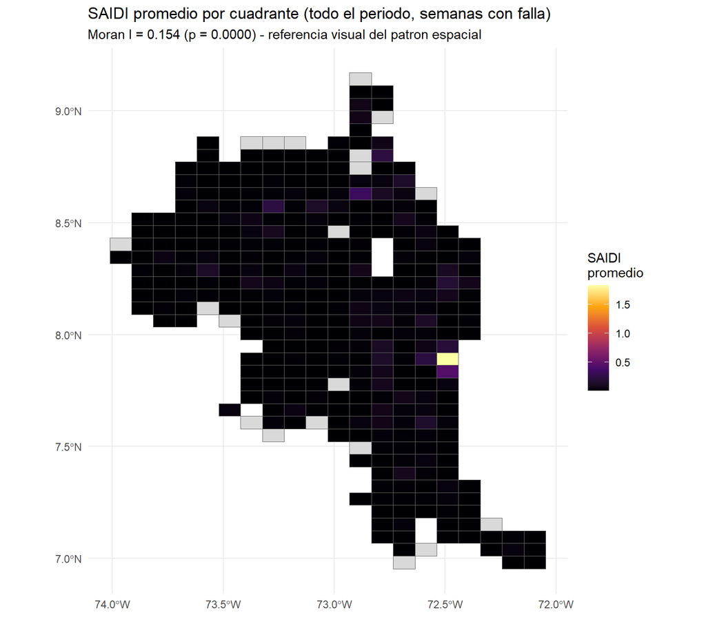

```r
cuadrantes_infra %>%
  left_join(saidi_promedio_cuadrante, by = "id_cuadrante") %>%
  ggplot() +
  geom_sf(aes(fill = SAIDI_promedio), color = "gray40", linewidth = 0.15) +
  scale_fill_viridis_c(option = "inferno", na.value = "grey85", name = "SAIDI\npromedio") +
  labs(
    title    = "SAIDI promedio por cuadrante (todo el periodo, semanas con falla)",
    subtitle = sprintf("Moran I = %.3f (p = %.4f) - referencia visual del patron espacial",
                       moran_resultado$estimate[1], moran_resultado$p.value)
  ) +
  theme_minimal(base_size = 11)
```

## Construcción del rezago espacial

Para cada cuadrante y semana, se calcula el **promedio de sus vecinos inmediatos**:

- `SAIDI_vecinos_lag1`: SAIDI de los vecinos en la **semana anterior** (rezagado deliberadamente, para no filtrar información contemporánea del propio cuadrante hacia sí mismo a través de sus vecinos).
- `n_eventos_vecinos`, `ndvi_vecinos`: variables **contemporáneas**, porque son exógenas al SAIDI del propio cuadrante — no hay riesgo de fuga de información al usarlas sin rezago.

```r
matriz_pesos <- listw2mat(pesos_espaciales)
rownames(matriz_pesos) <- cuadrantes_infra$id_cuadrante
colnames(matriz_pesos) <- cuadrantes_infra$id_cuadrante

calcular_rezago_espacial <- function(datos, variable, usar_lag_temporal = FALSE) {

  var_sym <- rlang::sym(variable)

  ancho <- datos %>%
    select(id_cuadrante, semana, !!var_sym) %>%
    tidyr::pivot_wider(names_from = id_cuadrante, values_from = !!var_sym)

  semanas_vec <- ancho$semana
  mat_valores <- as.matrix(ancho %>% select(-semana))
  mat_valores <- mat_valores[, colnames(matriz_pesos), drop = FALSE]
  mat_valores[is.na(mat_valores)] <- 0

  if (usar_lag_temporal) {
    mat_valores <- rbind(matrix(NA, nrow = 1, ncol = ncol(mat_valores),
                                 dimnames = list(NULL, colnames(mat_valores))),
                          mat_valores[-nrow(mat_valores), ])
    mat_valores[is.na(mat_valores)] <- 0
  }

  rezago <- mat_valores %*% t(matriz_pesos)
  colnames(rezago) <- colnames(mat_valores)

  as.data.frame(rezago) %>%
    mutate(semana = semanas_vec) %>%
    tidyr::pivot_longer(-semana, names_to = "id_cuadrante", values_to = paste0(variable, "_vecinos"))
}

saidi_vecinos <- calcular_rezago_espacial(data_final, "SAIDI", usar_lag_temporal = TRUE) %>%
  rename(SAIDI_vecinos_lag1 = SAIDI_vecinos)

eventos_vecinos <- calcular_rezago_espacial(data_final, "n_eventos_catastroficos") %>%
  rename(n_eventos_vecinos = n_eventos_catastroficos_vecinos)

ndvi_vecinos <- calcular_rezago_espacial(data_final, "ndvi_semanal") %>%
  rename(ndvi_vecinos = ndvi_semanal_vecinos)

data_final <- data_final %>%
  select(-any_of(c("SAIDI_vecinos_lag1", "n_eventos_vecinos", "ndvi_vecinos"))) %>%
  left_join(saidi_vecinos,   by = c("id_cuadrante", "semana")) %>%
  left_join(eventos_vecinos, by = c("id_cuadrante", "semana")) %>%
  left_join(ndvi_vecinos,    by = c("id_cuadrante", "semana"))

cat(sprintf(
  "Variables de rezago espacial construidas.\nCobertura SAIDI_vecinos_lag1: %.1f%%\nCobertura n_eventos_vecinos: %.1f%%\nCobertura ndvi_vecinos: %.1f%%\n",
  100 * mean(!is.na(data_final$SAIDI_vecinos_lag1)),
  100 * mean(!is.na(data_final$n_eventos_vecinos)),
  100 * mean(!is.na(data_final$ndvi_vecinos))
))
```

```
## Variables de rezago espacial construidas.
## Cobertura SAIDI_vecinos_lag1: 100.0%
## Cobertura n_eventos_vecinos: 100.0%
## Cobertura ndvi_vecinos: 100.0%
```

## Verificación visual: ¿el rezago espacial se relaciona con SAIDI del cuadrante?

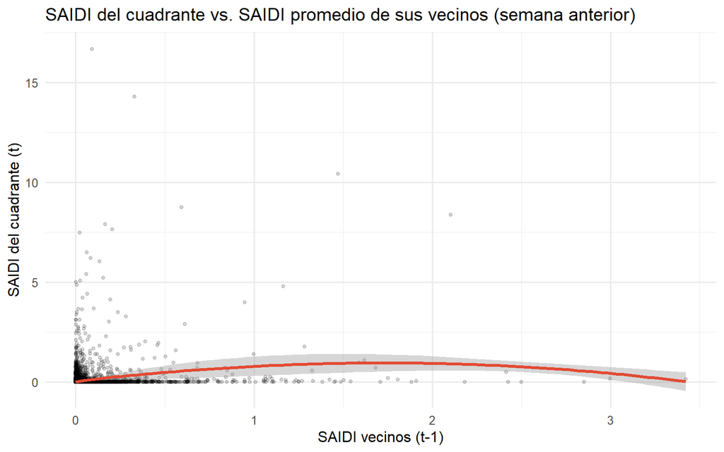

```r
data_final %>%
  filter(hubo_falla == 1) %>%
  ggplot(aes(x = SAIDI_vecinos_lag1, y = SAIDI)) +
  geom_point(alpha = 0.15, size = 1) +
  geom_smooth(method = "loess", color = "#e34a33", se = TRUE) +
  labs(
    title = "SAIDI del cuadrante vs. SAIDI promedio de sus vecinos (semana anterior)",
    x = "SAIDI vecinos (t-1)", y = "SAIDI del cuadrante (t)"
  ) +
  theme_minimal(base_size = 12)
```

**Nota de rendimiento:** `poly2nb()` sobre 344 polígonos es rápido (segundos); `calcular_rezago_espacial()` reestructura el panel a formato ancho (semana × cuadrante) tres veces — con ~344 cuadrantes y ~100 semanas esto es manejable, no debería tardar más de uno o dos minutos en total.

## Selección de variables candidatas

```r
vars_candidatas <- c(
  # Climáticas (dinámicas)
  "temp_media_semana", "temp_max_semana", "humedad_media_semana",
  "viento_max_semana", "precip_total_semana", "precip_ma4", "viento_ma4",
  # Vegetación (dinámica)
  "ndvi_semanal", "log_ndvi",
  # Infraestructura (estática)
  "n_elementos", "n_tipos_infraestructura", "prop_transformadores",
  # Topología de red eléctrica (estática) — incorporada en el
  # documento de topología (grafo, longitud de línea, nodos terminales)
  "longitud_red_km", "n_circuitos_cuadrante", "n_nodos_terminales", "densidad_terminales",
  # Estrato y tipo de uso REAL por cuadrante (estático) — reemplaza al
  # estrato_predominante_municipal, ahora con precisión de cuadrante
  "estrato_modal_real", "prop_estrato_1", "prop_estrato_2", "prop_estrato_3",
  "prop_estrato_4", "prop_estrato_5", "prop_estrato_6",
  "prop_industrial", "prop_comercial", "prop_oficial", "prop_no_residencial",
  # Activos: edad y mantenimiento (estático/casi-estático) — resuelve
  # el hueco de variables "operativas" identificado frente a los
  # objetivos de tesis
  "edad_activo_mas_viejo_anios", "edad_activo_mas_nuevo_anios",
  "rango_edad_activos_anios", "PROM_CANT_MODIFICACIONES",
  # Desastres (dinámica, municipal)
  "n_eventos_catastroficos", "hubo_evento_catastrofico",
  # Sismicidad (dinámica, distancia real)
  "n_sismos_r50", "n_sismos_m3_r50", "magnitud_max_r50", "dist_sismo_min_km_r50",
  # Rezagos temporales
  "SAIDI_lag1", "SAIFI_lag1", "SAIDI_lag4",
  # Interacciones
  "ndvi_x_elementos", "sismo_x_elementos",
  # Rezago espacial (vecinos, geográfico)
  "SAIDI_vecinos_lag1", "n_eventos_vecinos", "ndvi_vecinos"
)

vars_disponibles <- intersect(vars_candidatas, names(data_final))
cat(sprintf("Variables candidatas disponibles: %d de %d\n",
            length(vars_disponibles), length(vars_candidatas)))
```

```
## Variables candidatas disponibles: 45 de 45
```

```r
print(setdiff(vars_candidatas, names(data_final)))
```

```
## character(0)
```

## Matriz de correlación (colinealidad)

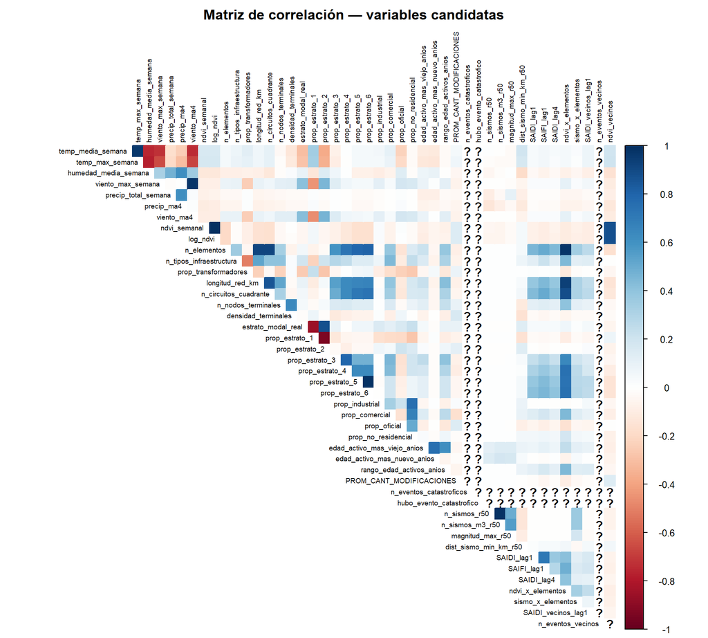

```r
vars_numericas <- data_final %>%
  select(all_of(vars_disponibles)) %>%
  select(where(is.numeric)) %>%
  na.omit()

if (nrow(vars_numericas) > 100) {
  cor_mat <- cor(vars_numericas, use = "complete.obs")
  corrplot(cor_mat, method = "color", type = "upper", tl.cex = 0.6,
           tl.col = "black", diag = FALSE,
           title = "Matriz de correlación — variables candidatas", mar = c(0,0,2,0))
} else {
  message("Muy pocas filas completas para calcular correlaciones de forma robusta.")
}
```

# Parte 2 — Análisis exploratorio de relaciones

## SAIDI/SAIFI vs. variables climáticas

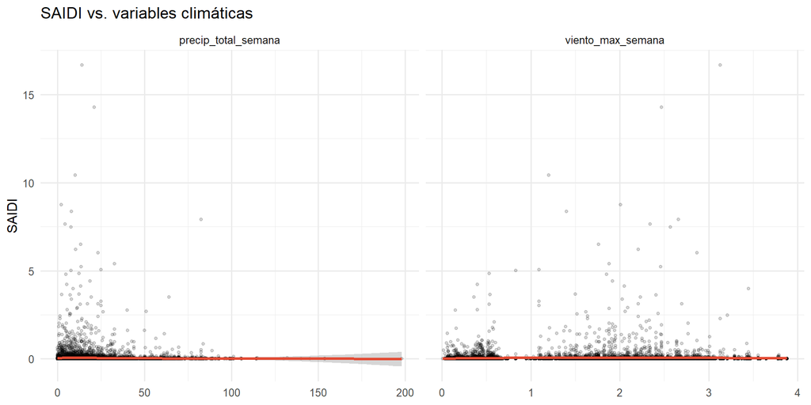

```r
data_final %>%
  filter(hubo_falla == 1) %>%
  select(SAIDI, precip_total_semana, viento_max_semana) %>%
  pivot_longer(-SAIDI, names_to = "variable", values_to = "valor") %>%
  ggplot(aes(x = valor, y = SAIDI)) +
  geom_point(alpha = 0.15, size = 1) +
  geom_smooth(method = "loess", color = "#e34a33", se = TRUE) +
  facet_wrap(~variable, scales = "free_x") +
  labs(title = "SAIDI vs. variables climáticas", x = NULL, y = "SAIDI") +
  theme_minimal(base_size = 12)
```

## SAIDI/SAIFI vs. exposición sísmica y NDVI

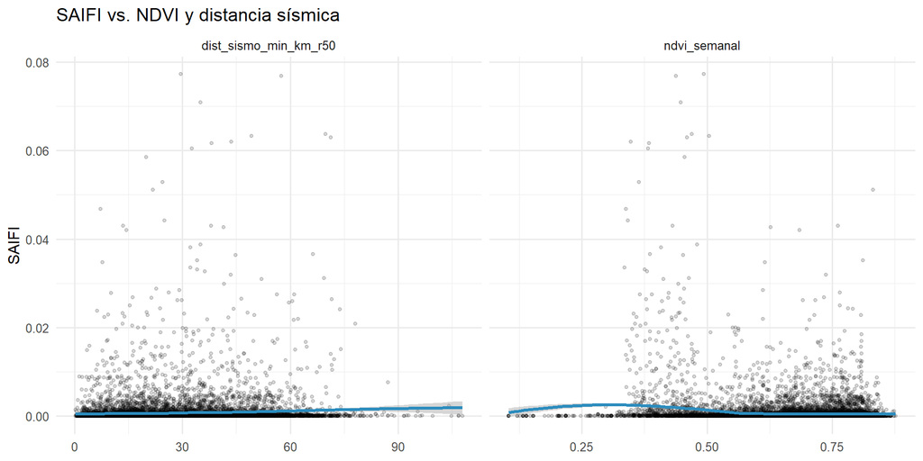

```r
data_final %>%
  filter(hubo_falla == 1) %>%
  select(SAIFI, ndvi_semanal, dist_sismo_min_km_r50) %>%
  pivot_longer(-SAIFI, names_to = "variable", values_to = "valor") %>%
  filter(!is.na(valor)) %>%
  ggplot(aes(x = valor, y = SAIFI)) +
  geom_point(alpha = 0.15, size = 1) +
  geom_smooth(method = "loess", color = "#2b8cbe", se = TRUE) +
  facet_wrap(~variable, scales = "free_x") +
  labs(title = "SAIFI vs. NDVI y distancia sísmica", x = NULL, y = "SAIFI") +
  theme_minimal(base_size = 12)
```

## Distribución de SAIDI/SAIFI (justificación de la transformación log)

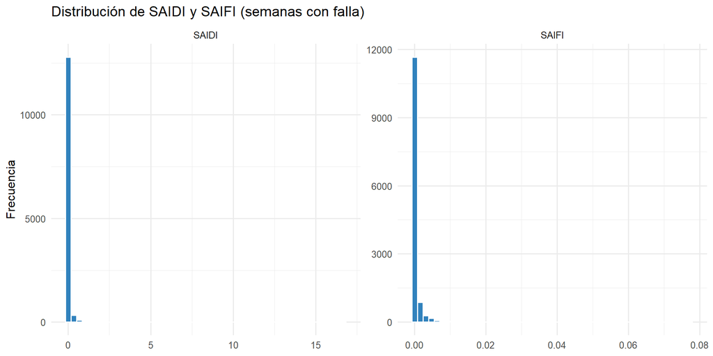

```r
data_final %>%
  filter(hubo_falla == 1) %>%
  select(SAIDI, SAIFI) %>%
  pivot_longer(everything(), names_to = "indicador", values_to = "valor") %>%
  ggplot(aes(x = valor)) +
  geom_histogram(bins = 50, fill = "#3182bd", color = "white") +
  facet_wrap(~indicador, scales = "free") +
  labs(title = "Distribución de SAIDI y SAIFI (semanas con falla)", x = NULL, y = "Frecuencia") +
  theme_minimal(base_size = 12)
```

# Parte 3 — Preparación del split temporal (train / test)

**No se usa partición aleatoria.** Se reservan las últimas semanas del panel como conjunto de prueba (*holdout* temporal), simulando un escenario real de pronóstico: entrenar con el pasado, predecir el futuro.

```r
PCT_TEST <- 0.15   # últimas semanas como test

semanas_ordenadas <- data_final %>% distinct(semana) %>% arrange(semana) %>% pull(semana)
n_semanas <- length(semanas_ordenadas)
corte <- semanas_ordenadas[floor(n_semanas * (1 - PCT_TEST))]

train <- data_final %>% filter(semana <= corte, hubo_falla == 1)
test  <- data_final %>% filter(semana >  corte, hubo_falla == 1)

cat(sprintf(
  "Corte temporal: %s\nTrain: %d filas (%s a %s)\nTest:  %d filas (%s a %s)\n",
  corte,
  nrow(train), min(train$semana), max(train$semana),
  nrow(test),  min(test$semana),  max(test$semana)
))
```

```
## Corte temporal: 2025-09-08
## Train: 11136 filas (2024-01-01 a 2025-09-08)
## Test:  2215 filas (2025-09-15 a 2025-12-29)
```

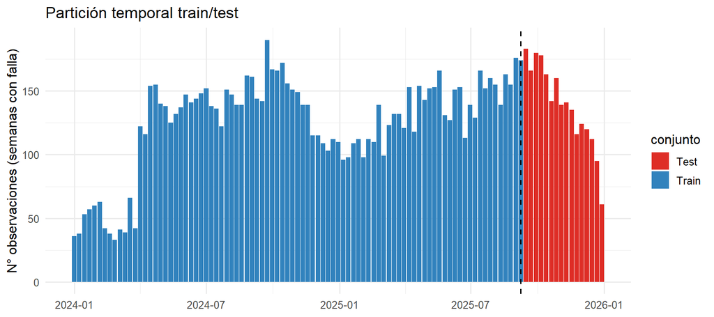

```r
data_final %>%
  filter(hubo_falla == 1) %>%
  mutate(conjunto = if_else(semana <= corte, "Train", "Test")) %>%
  count(semana, conjunto) %>%
  ggplot(aes(x = semana, y = n, fill = conjunto)) +
  geom_col() +
  geom_vline(xintercept = as.numeric(corte), linetype = "dashed") +
  scale_fill_manual(values = c(Train = "#3182bd", Test = "#de2d26")) +
  labs(title = "Partición temporal train/test", x = NULL, y = "N° observaciones (semanas con falla)") +
  theme_minimal(base_size = 12)
```

# Parte 4 — Especificaciones de modelo

Se comparan cuatro enfoques progresivamente más flexibles, todos entrenados con exactamente las mismas variables disponibles y evaluados sobre el mismo *test* temporal:

1. **Pooled OLS** (referencia simple, ignora estructura de panel).
2. **Panel con efectos fijos de cuadrante** (`fixest::feols`) — controla heterogeneidad no observada constante por cuadrante; las variables estáticas quedan absorbidas por diseño.
3. **Panel con efectos fijos de cuadrante + semana** (controla también shocks comunes a todos los cuadrantes en una semana dada, como una ola de frío regional).
4. **Random Forest** (no lineal, captura interacciones sin especificarlas a mano) — como referencia de techo de desempeño predictivo.

Variable respuesta: `log1p(SAIDI)` (para manejar la cola larga).

```r
vars_modelo <- c(
  "temp_media_semana", "viento_max_semana", "precip_total_semana", "precip_ma4",
  "ndvi_semanal", "n_eventos_catastroficos", "n_sismos_r50", "dist_sismo_min_km_r50",
  "SAIDI_lag1",
  # Topología de red eléctrica: longitud de línea (exposición física
  # real, más precisa que n_elementos) y densidad de nodos terminales
  # (puntas de ramal, mayor riesgo esperado en redes radiales). Son
  # estáticas -> se identifican en Pooled OLS, pero quedan absorbidas
  # por el efecto fijo en los modelos FE (mismo tratamiento que
  # n_elementos/prop_transformadores).
  "longitud_red_km", "densidad_terminales",
  # Composición socioeconómica REAL por cuadrante (reemplaza estrato
  # municipal): proporción de estratos bajos y de uso no residencial
  "prop_estrato_1", "prop_estrato_2", "prop_no_residencial",
  # Activos: edad y mantenimiento — variable nueva que resuelve el
  # hueco de "condición de la red" frente a los objetivos de tesis
  "edad_activo_mas_viejo_anios", "PROM_CANT_MODIFICACIONES",
  # Rezago espacial: se incluyen aquí porque el test de Moran's I
  # (Parte 1b) confirmó/sugirió señal espacial en SAIDI. Si el test
  # dio NO significativo en tu corrida, puedes comentar estas tres
  # líneas y comparar el desempeño con/sin ellas.
  "SAIDI_vecinos_lag1", "n_eventos_vecinos", "ndvi_vecinos"
)
vars_modelo <- intersect(vars_modelo, names(data_final))

formula_pooled <- as.formula(paste("log_SAIDI1 ~", paste(vars_modelo, collapse = " + ")))
cat("Fórmula base:\n"); print(formula_pooled)
```

```
## Fórmula base:
```

```
## log_SAIDI1 ~ temp_media_semana + viento_max_semana + precip_total_semana +
##     precip_ma4 + ndvi_semanal + n_eventos_catastroficos + n_sismos_r50 +
##     dist_sismo_min_km_r50 + SAIDI_lag1 + longitud_red_km + densidad_terminales +
##     prop_estrato_1 + prop_estrato_2 + prop_no_residencial + edad_activo_mas_viejo_anios +
##     PROM_CANT_MODIFICACIONES + SAIDI_vecinos_lag1 + n_eventos_vecinos +
##     ndvi_vecinos
```

## Modelo 1 — Pooled OLS

```r
m1_pooled <- feols(formula_pooled, data = train)
summary(m1_pooled)
```

```
## OLS estimation, Dep. Var.: log_SAIDI1
## Observations: 11,004
## Standard-errors: IID
##                              Estimate Std. Error   t value   Pr(>|t|)
## (Intercept)                 -0.120203 0.02992803 -4.016401 5.9487e-05 ***
## temp_media_semana            0.001438 0.00039802  3.613169 3.0383e-04 ***
## viento_max_semana            0.002126 0.00168281  1.263519 2.0643e-01
## precip_total_semana          0.000134 0.00007439  1.805149 7.1079e-02 .
## precip_ma4                   0.000058 0.00012175  0.477135 6.3328e-01
## ndvi_semanal                 0.032666 0.02387862  1.368016 1.7133e-01
## n_sismos_r50                -0.000024 0.00000700 -3.453017 5.5644e-04 ***
## dist_sismo_min_km_r50        0.000262 0.00007743  3.380520 7.2601e-04 ***
## SAIDI_lag1                   0.063883 0.00332421 19.217632  < 2.2e-16 ***
## longitud_red_km              0.001268 0.00003323 38.143846  < 2.2e-16 ***
## densidad_terminales         -0.003017 0.00166858 -1.808199 7.0603e-02 .
## prop_estrato_1              -0.011198 0.02344020 -0.477708 6.3287e-01
## prop_estrato_2               0.000779 0.02313320  0.033690 9.7313e-01
## prop_no_residencial         -0.043922 0.05509126 -0.797262 4.2532e-01
## edad_activo_mas_viejo_anios -0.005954 0.00185373 -3.211656 1.3235e-03 **
## PROM_CANT_MODIFICACIONES     0.024171 0.00629858  3.837505 1.2499e-04 ***
## SAIDI_vecinos_lag1           0.044054 0.00900917  4.889852 1.0234e-06 ***
## ndvi_vecinos                 0.001615 0.03042290  0.053095 9.5766e-01
## ---
## Signif. codes:  0 '***' 0.001 '**' 0.01 '*' 0.05 '.' 0.1 ' ' 1
## RMSE: 0.116618   Adj. R2: 0.298506
```

## Modelo 2 — Efectos fijos de cuadrante

```r
formula_fe <- as.formula(paste("log_SAIDI1 ~", paste(vars_modelo, collapse = " + "), "| id_cuadrante"))

m2_fe_cuadrante <- feols(formula_fe, data = train)
summary(m2_fe_cuadrante)
```

```
## OLS estimation, Dep. Var.: log_SAIDI1
## Observations: 10,992
## Fixed-effects: id_cuadrante: 310
## Standard-errors: IID
##                              Estimate Std. Error   t value   Pr(>|t|)
## temp_media_semana            0.002196 0.00122909  1.786585 7.4033e-02 .
## viento_max_semana            0.003458 0.00312267  1.107528 2.6809e-01
## precip_total_semana          0.000134 0.00007484  1.792616 7.3063e-02 .
## precip_ma4                   0.000180 0.00013116  1.372212 1.7003e-01
## ndvi_semanal                 0.018489 0.04106762  0.450208 6.5257e-01
## n_sismos_r50                -0.000017 0.00000757 -2.180623 2.9233e-02 *
## dist_sismo_min_km_r50        0.000114 0.00008608  1.326204 1.8480e-01
## SAIDI_lag1                   0.044766 0.00336113 13.318666  < 2.2e-16 ***
## prop_estrato_1              -0.280688 0.18388839 -1.526402 1.2694e-01
## prop_estrato_2              -0.204357 0.19241573 -1.062061 2.8823e-01
## prop_no_residencial         -0.259802 0.61989500 -0.419106 6.7515e-01
## edad_activo_mas_viejo_anios  0.002493 0.00310778  0.802021 4.2256e-01
## SAIDI_vecinos_lag1           0.064292 0.00992039  6.480836 9.5240e-11 ***
## ndvi_vecinos                 0.050962 0.04616391  1.103926 2.6965e-01
## ... 3 variables were removed because of collinearity (longitud_red_km,
## densidad_terminales and PROM_CANT_MODIFICACIONES)
## ---
## Signif. codes:  0 '***' 0.001 '**' 0.01 '*' 0.05 '.' 0.1 ' ' 1
## RMSE: 0.11267     Adj. R2: 0.32711
##                 Within R2: 0.024787
```

## Modelo 3 — Efectos fijos de cuadrante + semana

```r
formula_fe2 <- as.formula(paste("log_SAIDI1 ~", paste(vars_modelo, collapse = " + "), "| id_cuadrante + semana"))

m3_fe_doble <- feols(formula_fe2, data = train)
summary(m3_fe_doble)
```

```
## OLS estimation, Dep. Var.: log_SAIDI1
## Observations: 10,992
## Fixed-effects: id_cuadrante: 310,  semana: 86
## Standard-errors: IID
##                        Estimate Std. Error   t value   Pr(>|t|)
## temp_media_semana      0.003636   0.002059  1.766342 7.7367e-02 .
## viento_max_semana      0.005110   0.004604  1.109933 2.6705e-01
## precip_total_semana    0.000286   0.000194  1.471227 1.4126e-01
## precip_ma4            -0.000496   0.000349 -1.418758 1.5600e-01
## ndvi_semanal           0.011601   0.041015  0.282834 7.7731e-01
## dist_sismo_min_km_r50 -0.000054   0.000095 -0.562246 5.7396e-01
## SAIDI_lag1             0.043010   0.003359 12.802763  < 2.2e-16 ***
## prop_estrato_1        -0.306156   0.183531 -1.668145 9.5316e-02 .
## prop_estrato_2        -0.224219   0.192110 -1.167140 2.4318e-01
## prop_no_residencial   -0.368530   0.619704 -0.594686 5.5207e-01
## SAIDI_vecinos_lag1     0.056261   0.010065  5.589824 2.3293e-08 ***
## ndvi_vecinos           0.006698   0.049731  0.134685 8.9286e-01
## ... 5 variables were removed because of collinearity (n_sismos_r50,
## longitud_red_km and 3 others [full set in $collin.var])
## ---
## Signif. codes:  0 '***' 0.001 '**' 0.01 '*' 0.05 '.' 0.1 ' ' 1
## RMSE: 0.11173     Adj. R2: 0.33311
##                 Within R2: 0.020961
```

## Modelo 4 — Random Forest

```r
train_rf <- train %>% select(log_SAIDI1, all_of(vars_modelo)) %>% na.omit()
test_rf  <- test  %>% select(log_SAIDI1, all_of(vars_modelo)) %>% na.omit()

set.seed(123)
m4_rf <- randomForest(
  log_SAIDI1 ~ ., data = train_rf,
  ntree = 500, importance = TRUE
)

print(m4_rf)
```

```
##
## Call:
##  randomForest(formula = log_SAIDI1 ~ ., data = train_rf, ntree = 500,      importance = TRUE)
##                Type of random forest: regression
##                      Number of trees: 500
## No. of variables tried at each split: 6
##
##           Mean of squared residuals: 0.01299939
##                     % Var explained: 33.05
```

### Importancia de variables — Random Forest

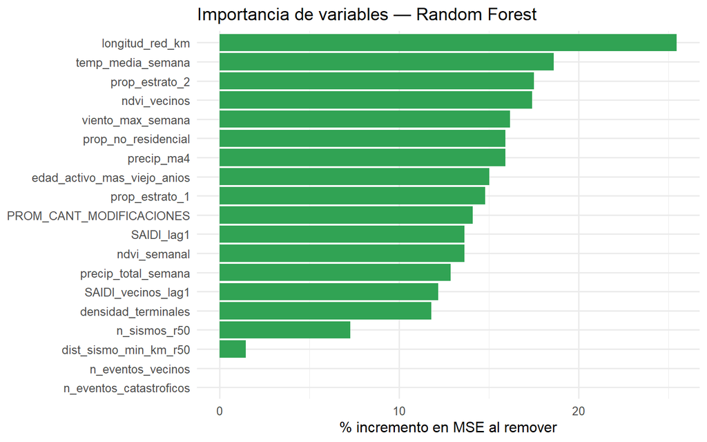

```r
importancia_rf <- importance(m4_rf) %>%
  as.data.frame() %>%
  tibble::rownames_to_column("variable") %>%
  arrange(desc(`%IncMSE`))

ggplot(importancia_rf, aes(x = reorder(variable, `%IncMSE`), y = `%IncMSE`)) +
  geom_col(fill = "#31a354") +
  coord_flip() +
  labs(title = "Importancia de variables — Random Forest", x = NULL, y = "% incremento en MSE al remover") +
  theme_minimal(base_size = 12)
```

# Parte 5 — Evaluación sobre el conjunto de prueba (test temporal)

```r
test_completo <- test %>% select(log_SAIDI1, SAIDI, all_of(vars_modelo), id_cuadrante, semana) %>% na.omit()

pred_pooled <- predict(m1_pooled, newdata = test_completo)
pred_fe1    <- predict(m2_fe_cuadrante, newdata = test_completo)
pred_fe2    <- predict(m3_fe_doble, newdata = test_completo)
pred_rf     <- predict(m4_rf, newdata = test_completo)

# NOTA: predict.fixest() puede devolver NA para filas cuyo id_cuadrante
# no tenga suficiente historia en train para estimar su efecto fijo.
# Se reporta el conteo y se calculan las métricas SOLO sobre filas
# válidas, para no propagar NA a RMSE/MAE/R2 completos.
cat(sprintf(
  "NA en predicciones — Pooled: %d | FE cuadrante: %d | FE cuadrante+semana: %d | RF: %d (de %d filas)\n",
  sum(is.na(pred_pooled)), sum(is.na(pred_fe1)), sum(is.na(pred_fe2)), sum(is.na(pred_rf)),
  nrow(test_completo)
))
```

```
## NA en predicciones — Pooled: 0 | FE cuadrante: 7 | FE cuadrante+semana: 2215 | RF: 0 (de 2215 filas)
```

```r
calc_metricas_validas <- function(observado, predicho) {
  valido <- !is.na(predicho) & !is.na(observado)
  if (sum(valido) < 5) return(c(RMSE = NA_real_, MAE = NA_real_, R2 = NA_real_))
  c(
    RMSE = Metrics::rmse(observado[valido], predicho[valido]),
    MAE  = Metrics::mae(observado[valido], predicho[valido]),
    R2   = cor(observado[valido], predicho[valido])^2
  )
}

m_pooled_metricas <- calc_metricas_validas(test_completo$log_SAIDI1, pred_pooled)
m_fe1_metricas    <- calc_metricas_validas(test_completo$log_SAIDI1, pred_fe1)
m_fe2_metricas    <- calc_metricas_validas(test_completo$log_SAIDI1, pred_fe2)
m_rf_metricas     <- calc_metricas_validas(test_completo$log_SAIDI1, pred_rf)

resultados <- tibble(
  modelo   = c("Pooled OLS", "FE cuadrante", "FE cuadrante+semana", "Random Forest"),
  RMSE_log = c(m_pooled_metricas["RMSE"], m_fe1_metricas["RMSE"], m_fe2_metricas["RMSE"], m_rf_metricas["RMSE"]),
  MAE_log  = c(m_pooled_metricas["MAE"],  m_fe1_metricas["MAE"],  m_fe2_metricas["MAE"],  m_rf_metricas["MAE"]),
  R2_log   = c(m_pooled_metricas["R2"],   m_fe1_metricas["R2"],   m_fe2_metricas["R2"],   m_rf_metricas["R2"])
)

kable(resultados, digits = 4,
      caption = "Desempeño comparado en el conjunto de prueba (escala log1p(SAIDI))") %>%
  kable_styling(bootstrap_options = c("striped", "hover"), full_width = FALSE)
```

Desempeño comparado en el conjunto de prueba (escala log1p(SAIDI))

| modelo | RMSE_log | MAE_log | R2_log |
| --- | --- | --- | --- |
| Pooled OLS | 0.1666 | 0.0627 | 0.0558 |
| FE cuadrante | 0.1341 | 0.0517 | 0.1087 |
| FE cuadrante+semana | NA | NA | NA |
| Random Forest | 0.1195 | 0.0609 | 0.1902 |

## ¿Cuánto aporta específicamente el rezago espacial?

Se re-estima el modelo FE cuadrante **sin** las tres variables de vecindad, y se compara su RMSE en test contra la versión completa — así se aísla el aporte marginal de la dimensión espacial, en vez de asumir que ayuda solo porque se incluyó.

```r
vars_sin_espacial <- setdiff(vars_modelo, c("SAIDI_vecinos_lag1", "n_eventos_vecinos", "ndvi_vecinos"))

formula_fe_sin_espacial <- as.formula(
  paste("log_SAIDI1 ~", paste(vars_sin_espacial, collapse = " + "), "| id_cuadrante")
)

m2_fe_sin_espacial <- feols(formula_fe_sin_espacial, data = train)

test_sin_espacial <- test %>% select(log_SAIDI1, all_of(vars_sin_espacial), id_cuadrante) %>% na.omit()
pred_sin_espacial  <- predict(m2_fe_sin_espacial, newdata = test_sin_espacial)

cat(sprintf("NA en predicciones — sin espacial: %d de %d | con espacial: %d de %d\n",
            sum(is.na(pred_sin_espacial)), length(pred_sin_espacial),
            sum(is.na(pred_fe1)), length(pred_fe1)))
```

```
## NA en predicciones — sin espacial: 7 de 2215 | con espacial: 7 de 2215
```

```r
metricas_sin <- calc_metricas_validas(test_sin_espacial$log_SAIDI1, pred_sin_espacial)
metricas_con <- calc_metricas_validas(test_completo$log_SAIDI1, pred_fe1)

comparacion_espacial <- tibble(
  especificacion = c("FE cuadrante — SIN variables espaciales", "FE cuadrante — CON variables espaciales"),
  RMSE_log = c(metricas_sin["RMSE"], metricas_con["RMSE"]),
  R2_log   = c(metricas_sin["R2"], metricas_con["R2"])
)

kable(comparacion_espacial, digits = 4,
      caption = "Aporte marginal de las variables de vecindad espacial (mismo modelo FE cuadrante)") %>%
  kable_styling(bootstrap_options = c("striped"), full_width = FALSE)
```

Aporte marginal de las variables de vecindad espacial (mismo modelo FE cuadrante)

| especificacion | RMSE_log | R2_log |
| --- | --- | --- |
| FE cuadrante — SIN variables espaciales | 0.1377 | 0.1037 |
| FE cuadrante — CON variables espaciales | 0.1341 | 0.1087 |

```r
if (any(is.na(comparacion_espacial$RMSE_log))) {
  mejora_pct <- NA_real_
  cat("\nNo fue posible calcular el cambio en RMSE: alguna de las dos especificaciones no generó suficientes predicciones válidas (revisa el conteo de NA impreso arriba).\n")
} else {
  mejora_pct <- round(100 * (comparacion_espacial$RMSE_log[1] - comparacion_espacial$RMSE_log[2]) /
                       comparacion_espacial$RMSE_log[1], 1)
  cat(sprintf("\nCambio en RMSE al agregar variables espaciales: %.1f%% %s\n",
              abs(mejora_pct), if (mejora_pct > 0) "(mejora)" else "(empeora o sin cambio relevante)"))
}
```

```
##
## Cambio en RMSE al agregar variables espaciales: 2.6% (mejora)
```

## Gráfico: predicho vs. observado (mejor modelo según RMSE)

```r
mejor_modelo <- resultados$modelo[which.min(resultados$RMSE_log)]
cat(sprintf("Mejor modelo según RMSE en test: %s\n", mejor_modelo))
```

```
## Mejor modelo según RMSE en test: Random Forest
```

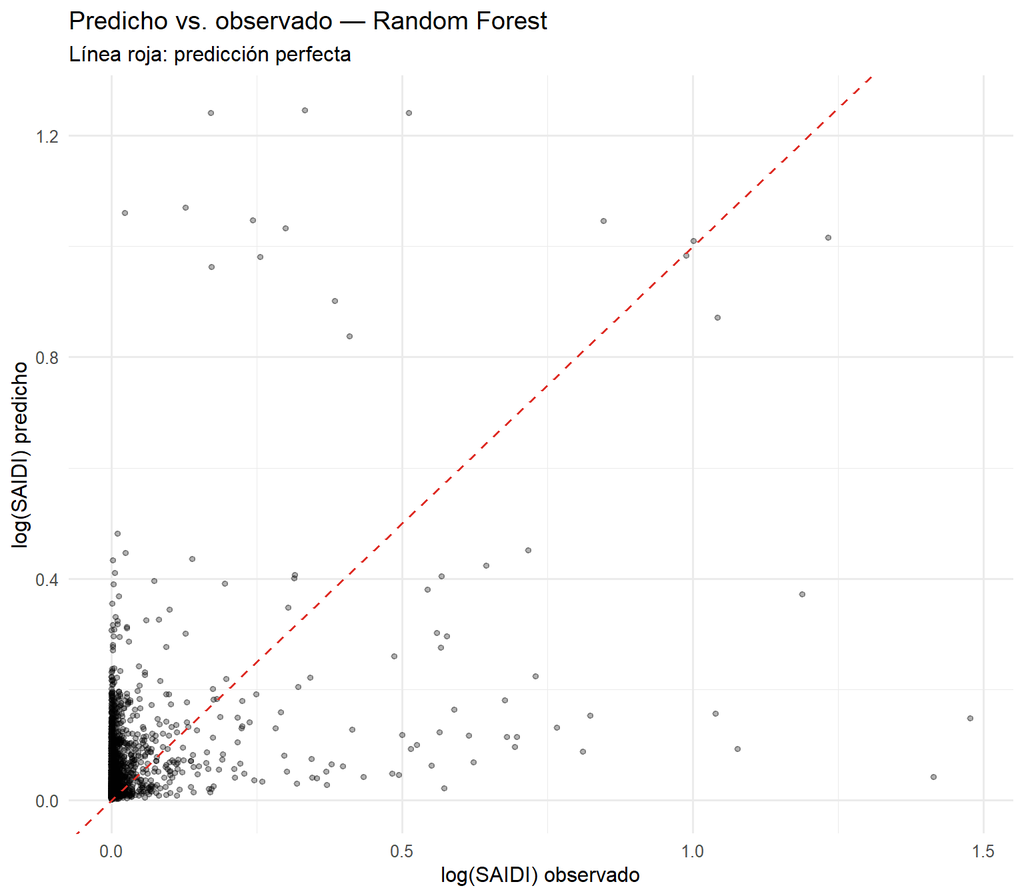

```r
pred_mejor <- switch(mejor_modelo,
  "Pooled OLS" = pred_pooled,
  "FE cuadrante" = pred_fe1,
  "FE cuadrante+semana" = pred_fe2,
  "Random Forest" = pred_rf
)

data.frame(observado = test_completo$log_SAIDI1, predicho = pred_mejor) %>%
  ggplot(aes(x = observado, y = predicho)) +
  geom_point(alpha = 0.3, size = 1.2) +
  geom_abline(slope = 1, intercept = 0, color = "#de2d26", linetype = "dashed") +
  labs(
    title = sprintf("Predicho vs. observado — %s", mejor_modelo),
    subtitle = "Línea roja: predicción perfecta",
    x = "log(SAIDI) observado", y = "log(SAIDI) predicho"
  ) +
  theme_minimal(base_size = 12)
```

## Gráfico: residuos vs. semana (¿el modelo empeora en el tiempo?)

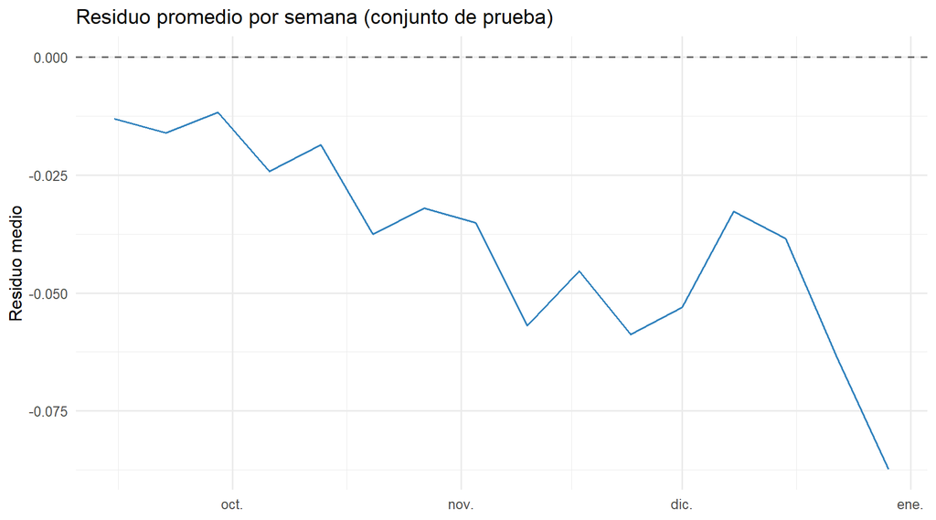

```r
test_completo %>%
  mutate(residuo = log_SAIDI1 - pred_mejor) %>%
  group_by(semana) %>%
  summarise(residuo_medio = mean(residuo), .groups = "drop") %>%
  ggplot(aes(x = semana, y = residuo_medio)) +
  geom_line(color = "#3182bd") +
  geom_hline(yintercept = 0, linetype = "dashed", color = "gray40") +
  labs(title = "Residuo promedio por semana (conjunto de prueba)", x = NULL, y = "Residuo medio") +
  theme_minimal(base_size = 12)
```

## Serie temporal: SAIDI real vs. pronosticado (muestra de cuadrantes)

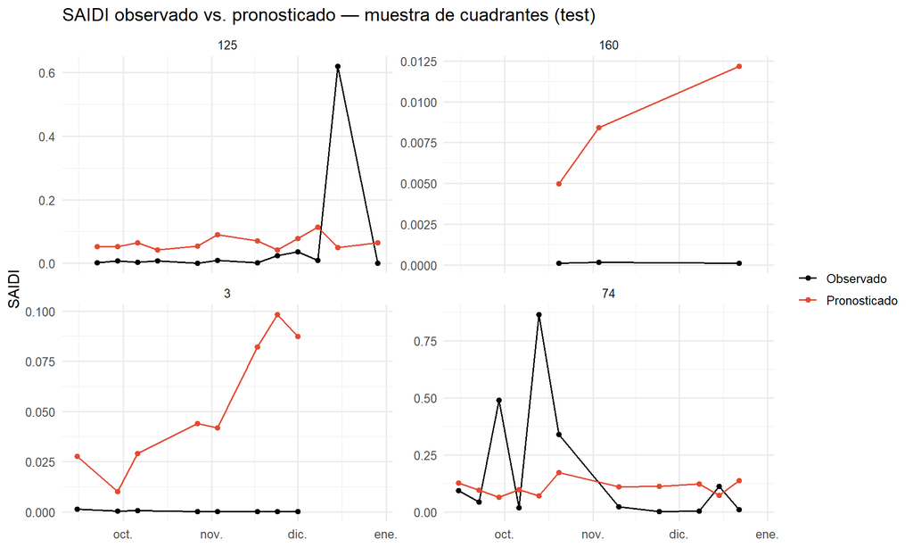

```r
set.seed(1)
muestra_cuad <- test_completo %>% distinct(id_cuadrante) %>% slice_sample(n = 4) %>% pull(id_cuadrante)

test_completo %>%
  mutate(SAIDI_pred = expm1(pred_mejor)) %>%
  filter(id_cuadrante %in% muestra_cuad) %>%
  select(id_cuadrante, semana, SAIDI, SAIDI_pred) %>%
  pivot_longer(c(SAIDI, SAIDI_pred), names_to = "tipo", values_to = "valor") %>%
  ggplot(aes(x = semana, y = valor, color = tipo)) +
  geom_line(linewidth = 0.7) +
  geom_point(size = 1.5) +
  facet_wrap(~id_cuadrante, scales = "free_y") +
  scale_color_manual(values = c(SAIDI = "black", SAIDI_pred = "#e34a33"),
                      labels = c("Observado", "Pronosticado")) +
  labs(title = "SAIDI observado vs. pronosticado — muestra de cuadrantes (test)",
       x = NULL, y = "SAIDI", color = NULL) +
  theme_minimal(base_size = 12)
```

# Parte 6 — Modelo equivalente para SAIFI

Se repite la comparación con SAIFI como variable respuesta. Con el denominador real por cuadrante (`usuarios_totales_cuadrante`), SAIFI ya no está acotado artificialmente a 1 ni dominado por el tamaño del cuadrante — puede superar ese valor si un cuadrante tuvo más de una interrupción por usuario en la misma semana. Se deja en escala original (sin log) como punto de partida; si la distribución resulta muy asimétrica en la práctica, conviene revisar `log1p(SAIFI)` como alternativa, igual que se hizo con SAIDI.

```r
formula_saifi_fe <- as.formula(paste("SAIFI ~", paste(vars_modelo, collapse = " + "), "| id_cuadrante"))

m_saifi_fe <- feols(formula_saifi_fe, data = train)
summary(m_saifi_fe)
```

```
## OLS estimation, Dep. Var.: SAIFI
## Observations: 10,992
## Fixed-effects: id_cuadrante: 310
## Standard-errors: IID
##                                 Estimate  Std. Error   t value   Pr(>|t|)
## temp_media_semana            0.000047805 0.000029448  1.623404 1.0453e-01
## viento_max_semana            0.000103847 0.000074816  1.388035 1.6516e-01
## precip_total_semana          0.000000146 0.000001793  0.081500 9.3505e-01
## precip_ma4                   0.000003575 0.000003143  1.137555 2.5533e-01
## ndvi_semanal                 0.000919179 0.000983933  0.934189 3.5023e-01
## n_sismos_r50                -0.000000190 0.000000181 -1.046246 2.9547e-01
## dist_sismo_min_km_r50        0.000002508 0.000002062  1.216031 2.2400e-01
## SAIDI_lag1                   0.000242375 0.000080529  3.009786 2.6204e-03 **
## prop_estrato_1               0.002585367 0.004405756  0.586816 5.5734e-01
## prop_estrato_2               0.004983831 0.004610061  1.081077 2.7969e-01
## prop_no_residencial         -0.009319569 0.014851976 -0.627497 5.3035e-01
## edad_activo_mas_viejo_anios -0.000014977 0.000074459 -0.201145 8.4059e-01
## SAIDI_vecinos_lag1           0.000939578 0.000237681  3.953100 7.7643e-05 ***
## ndvi_vecinos                -0.000510084 0.001106034 -0.461183 6.4468e-01
## ... 3 variables were removed because of collinearity (longitud_red_km,
## densidad_terminales and PROM_CANT_MODIFICACIONES)
## ---
## Signif. codes:  0 '***' 0.001 '**' 0.01 '*' 0.05 '.' 0.1 ' ' 1
## RMSE: 0.002699     Adj. R2: 0.296857
##                  Within R2: 0.003622
```

```r
test_saifi <- test %>% select(SAIFI, all_of(vars_modelo), id_cuadrante, semana) %>% na.omit()
pred_saifi <- predict(m_saifi_fe, newdata = test_saifi)

metricas_saifi <- calc_metricas_validas(test_saifi$SAIFI, pred_saifi)

cat(sprintf(
  "SAIFI — RMSE test: %.4f | MAE test: %.4f | R2: %.4f (n válido: %d de %d)\n",
  metricas_saifi["RMSE"], metricas_saifi["MAE"], metricas_saifi["R2"],
  sum(!is.na(pred_saifi) & !is.na(test_saifi$SAIFI)), length(pred_saifi)
))
```

```
## SAIFI — RMSE test: 0.0026 | MAE test: 0.0009 | R2: 0.2067 (n válido: 2208 de 2215)
```

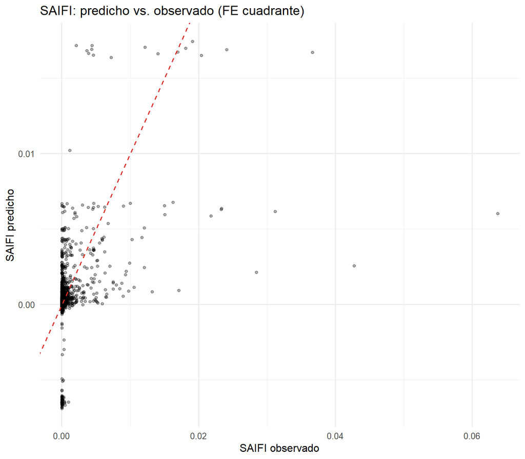

```r
data.frame(observado = test_saifi$SAIFI, predicho = pred_saifi) %>%
  ggplot(aes(x = observado, y = predicho)) +
  geom_point(alpha = 0.3, size = 1.2) +
  geom_abline(slope = 1, intercept = 0, color = "#de2d26", linetype = "dashed") +
  labs(title = "SAIFI: predicho vs. observado (FE cuadrante)", x = "SAIFI observado", y = "SAIFI predicho") +
  theme_minimal(base_size = 12)
```

# Parte 7 — Diagnóstico de supuestos (modelo FE cuadrante, SAIDI)

## Residuos vs. valores ajustados (homocedasticidad)

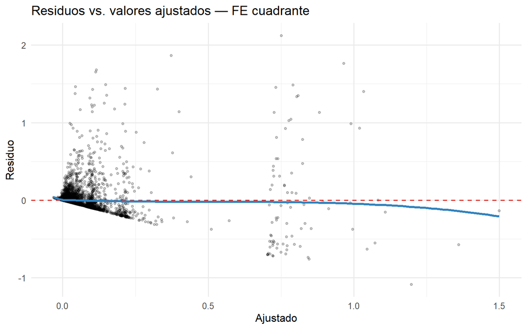

```r
train_diag <- train %>% select(log_SAIDI1, all_of(vars_modelo), id_cuadrante) %>% na.omit()

data.frame(
  ajustado = fitted(m2_fe_cuadrante),
  residuo  = resid(m2_fe_cuadrante)
) %>%
  ggplot(aes(x = ajustado, y = residuo)) +
  geom_point(alpha = 0.2, size = 1) +
  geom_hline(yintercept = 0, color = "#de2d26", linetype = "dashed") +
  geom_smooth(method = "loess", se = FALSE, color = "#3182bd") +
  labs(title = "Residuos vs. valores ajustados — FE cuadrante", x = "Ajustado", y = "Residuo") +
  theme_minimal(base_size = 12)
```

## QQ-plot de residuos (normalidad, relevante para inferencia)

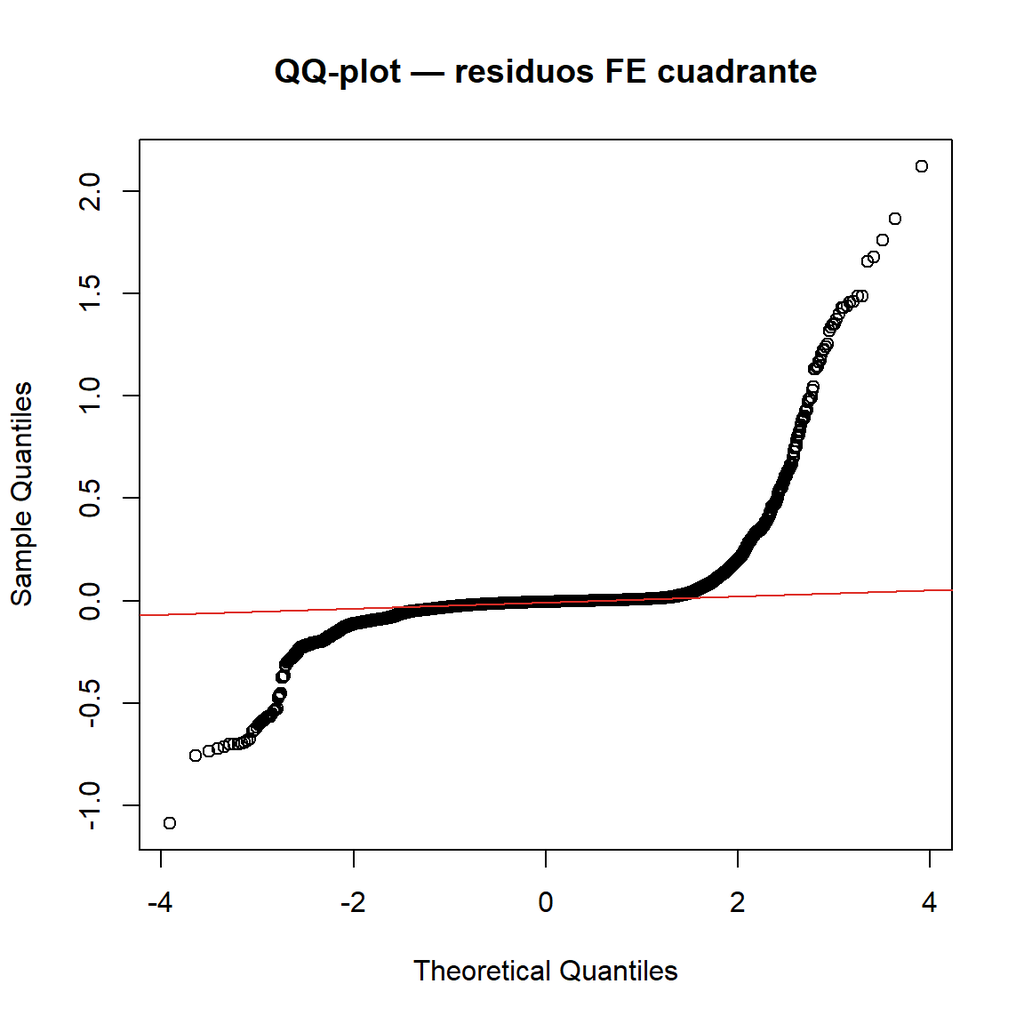

```r
qqnorm(resid(m2_fe_cuadrante), main = "QQ-plot — residuos FE cuadrante")
qqline(resid(m2_fe_cuadrante), col = "#de2d26")
```

## Comparación de especificaciones (tabla lado a lado)

```r
etable(m1_pooled, m2_fe_cuadrante, m3_fe_doble,
       headers = c("Pooled OLS", "FE cuadrante", "FE cuadrante+semana"))
```

```
##                                       m1_pooled     m2_fe_cuadrante
##                                      Pooled OLS        FE cuadrante
## Dependent Var.:                      log_SAIDI1          log_SAIDI1
##
## Constant                    -0.1202*** (0.0299)
## temp_media_semana            0.0014*** (0.0004)    0.0022. (0.0012)
## viento_max_semana               0.0021 (0.0017)     0.0035 (0.0031)
## precip_total_semana           0.0001. (7.44e-5)   0.0001. (7.48e-5)
## precip_ma4                     5.81e-5 (0.0001)     0.0002 (0.0001)
## ndvi_semanal                    0.0327 (0.0239)     0.0185 (0.0411)
## n_sismos_r50                 -2.42e-5*** (7e-6) -1.65e-5* (7.57e-6)
## dist_sismo_min_km_r50       0.0003*** (7.74e-5)    0.0001 (8.61e-5)
## SAIDI_lag1                   0.0639*** (0.0033)  0.0448*** (0.0034)
## longitud_red_km             0.0013*** (3.32e-5)
## densidad_terminales           -0.0030. (0.0017)
## prop_estrato_1                 -0.0112 (0.0234)    -0.2807 (0.1839)
## prop_estrato_2                  0.0008 (0.0231)    -0.2044 (0.1924)
## prop_no_residencial            -0.0439 (0.0551)    -0.2598 (0.6199)
## edad_activo_mas_viejo_anios  -0.0060** (0.0019)     0.0025 (0.0031)
## PROM_CANT_MODIFICACIONES     0.0242*** (0.0063)
## SAIDI_vecinos_lag1           0.0440*** (0.0090)  0.0643*** (0.0099)
## ndvi_vecinos                    0.0016 (0.0304)     0.0510 (0.0462)
## Fixed-Effects:              ------------------- -------------------
## id_cuadrante                                 No                 Yes
## semana                                       No                  No
## ___________________________ ___________________ ___________________
## S.E. type                                   IID                 IID
## Observations                             11,004              10,992
## R2                                      0.29959             0.34688
## Within R2                                    --             0.02479
##
##                                     m3_fe_doble
##                             FE cuadrante+semana
## Dependent Var.:                      log_SAIDI1
##
## Constant
## temp_media_semana              0.0036. (0.0021)
## viento_max_semana               0.0051 (0.0046)
## precip_total_semana             0.0003 (0.0002)
## precip_ma4                     -0.0005 (0.0003)
```

[output cut: 8 more lines]

```
## prop_no_residencial            -0.3685 (0.6197)
## edad_activo_mas_viejo_anios
## PROM_CANT_MODIFICACIONES
## SAIDI_vecinos_lag1           0.0563*** (0.0101)
## ndvi_vecinos                    0.0067 (0.0497)
## Fixed-Effects:               ------------------
## id_cuadrante                                Yes
## semana                                      Yes
## ___________________________  __________________
## S.E. type                                   IID
## Observations                             10,992
## R2                                      0.35774
## Within R2                               0.02096
## ---
## Signif. codes: 0 '***' 0.001 '**' 0.01 '*' 0.05 '.' 0.1 ' ' 1
```

# Parte 8 — Modelo espacial formal: SAR y SEM sobre corte transversal

La Parte 1b incorporó la dimensión espacial como una covariable (rezago espacial) dentro del panel. Esta sección va más allá: estima formalmente un **SAR** (*Spatial Autoregressive Model*) y un **SEM** (*Spatial Error Model*), que son los modelos espacialmente explícitos propiamente dichos — con un parámetro (`rho` o `lambda`) que mide la fuerza de la dependencia espacial, en vez de tratarla como una variable más.

## Paquetes

```r
if (!requireNamespace("spatialreg", quietly = TRUE)) install.packages("spatialreg")
```

```
##
##  C:\Users\ESILVAS\AppData\Local\Temp\Rtmpa6alNx\downloaded_packages
```

```r
library(spatialreg)
```

## Por qué un corte transversal, y por qué ponderado

`lagsarlm()`/`errorsarlm()` están pensados para una sola observación por unidad espacial, no para panel. Se colapsa el panel semanal a un **SAIDI representativo por cuadrante**, pero en vez de un promedio simple (que trata igual una semana de inicio del panel que la más reciente), se usa el **método de suma de dígitos** (misma lógica que la depreciación acelerada tipo “suma de años dígitos”): a cada semana se le asigna un peso creciente según su posición temporal, de forma que las observaciones **más recientes pesan más** — razonable porque el estado más reciente de la red (mantenimiento, deterioro, clima) es más informativo del riesgo actual que una falla ocurrida hace dos años.

$$w_t = \frac{t}{\sum_{k=1}^{n} k} =
\frac{t}{n(n+1)/2}, \qquad t = 1, \dots, n \text{ (1 = semana más
antigua, } n \text{ = más reciente)}$$

```r
# ------------------------------------------------------------------
# Promedio ponderado por suma de dígitos (peso lineal creciente en el
# tiempo) del SAIDI y SAIFI de cada cuadrante, usando TODAS las
# semanas del panel (no solo las que tuvieron falla), para que el
# denominador temporal sea el mismo para todos los cuadrantes.
# ------------------------------------------------------------------

pesos_temporales <- data_final %>%
  distinct(semana) %>%
  arrange(semana) %>%
  mutate(
    t = row_number(),
    n = n(),
    peso_digitos = t / (n * (n + 1) / 2)
  ) %>%
  select(semana, peso_digitos)

cat(sprintf("Semanas ponderadas: %d | Suma de pesos (debe ser 1): %.6f\n",
            nrow(pesos_temporales), sum(pesos_temporales$peso_digitos)))
```

```
## Semanas ponderadas: 105 | Suma de pesos (debe ser 1): 1.000000
```

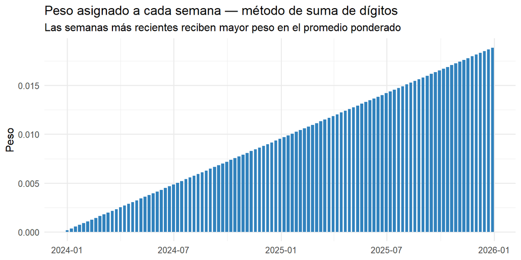

```r
ggplot(pesos_temporales, aes(x = semana, y = peso_digitos)) +
  geom_col(fill = "#3182bd", width = 5) +
  labs(
    title    = "Peso asignado a cada semana — método de suma de dígitos",
    subtitle = "Las semanas más recientes reciben mayor peso en el promedio ponderado",
    x = NULL, y = "Peso"
  ) +
  theme_minimal(base_size = 12)
```

```r
cross_section_cuadrante <- data_final %>%
  left_join(pesos_temporales, by = "semana") %>%
  group_by(id_cuadrante) %>%
  summarise(
    SAIDI_ponderado = sum(SAIDI * peso_digitos, na.rm = TRUE) / sum(peso_digitos[!is.na(SAIDI)]),
    SAIFI_ponderado = sum(SAIFI * peso_digitos, na.rm = TRUE) / sum(peso_digitos[!is.na(SAIFI)]),
    SAIDI_simple    = mean(SAIDI, na.rm = TRUE),   # referencia sin ponderar, para comparar
    # Predictores estáticos/agregados para el corte transversal
    n_elementos               = first(n_elementos),
    prop_transformadores      = first(prop_transformadores),
    longitud_red_km           = first(longitud_red_km),
    densidad_terminales       = first(densidad_terminales),
    n_circuitos_cuadrante     = first(n_circuitos_cuadrante),
    # Composición socioeconómica REAL por cuadrante (reemplaza estrato municipal)
    estrato_modal_real        = first(estrato_modal_real),
    prop_estrato_1            = first(prop_estrato_1),
    prop_estrato_2            = first(prop_estrato_2),
    prop_no_residencial       = first(prop_no_residencial),
    # Activos: edad y mantenimiento
    edad_activo_mas_viejo_anios = first(edad_activo_mas_viejo_anios),
    PROM_CANT_MODIFICACIONES    = first(PROM_CANT_MODIFICACIONES),
    ndvi_promedio             = mean(ndvi_semanal, na.rm = TRUE),
    dist_sismo_prom_km        = mean(dist_sismo_min_km_r50, na.rm = TRUE),
    precip_promedio           = mean(precip_total_semana, na.rm = TRUE),
    .groups = "drop"
  )

cat(sprintf("Corte transversal construido: %d cuadrantes\n", nrow(cross_section_cuadrante)))
```

```
## Corte transversal construido: 344 cuadrantes
```

## Comparación: promedio simple vs. ponderado por suma de dígitos

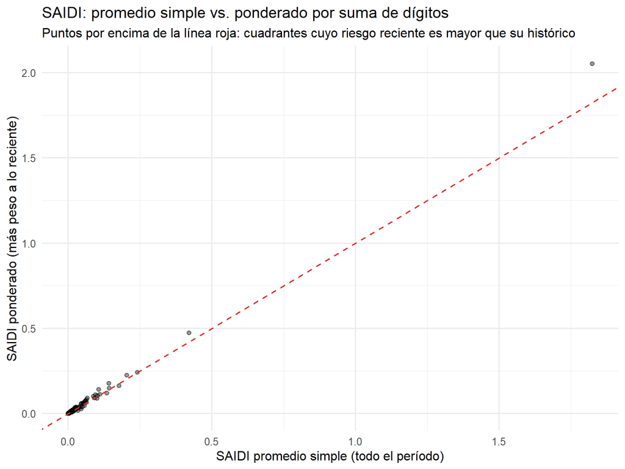

```r
cross_section_cuadrante %>%
  ggplot(aes(x = SAIDI_simple, y = SAIDI_ponderado)) +
  geom_point(alpha = 0.4) +
  geom_abline(slope = 1, intercept = 0, color = "#de2d26", linetype = "dashed") +
  labs(
    title    = "SAIDI: promedio simple vs. ponderado por suma de dígitos",
    subtitle = "Puntos por encima de la línea roja: cuadrantes cuyo riesgo reciente es mayor que su histórico",
    x = "SAIDI promedio simple (todo el período)", y = "SAIDI ponderado (más peso a lo reciente)"
  ) +
  theme_minimal(base_size = 12)
```

## Especificación base (misma para OLS, SAR y SEM)

Se define primero la fórmula, para poder filtrar el corte transversal por **todos** sus predictores antes de ajustar cualquier modelo — así `cross_section_sf`, la matriz de vecindad y los tres modelos (OLS, SAR, SEM) quedan siempre alineados en el mismo número de cuadrantes, sin depender de que cada función de ajuste descarte `NA` por su cuenta de forma silenciosa y desincronizada.

**Nota sobre el estrato:** `estrato_predominante_municipal` (municipal) se reemplaza aquí por `prop_estrato_1`/`prop_estrato_2` (composición socioeconómica real del propio cuadrante) — precisión de cuadrante en vez de precisión municipal.

```r
formula_espacial <- SAIDI_ponderado ~ n_elementos + prop_transformadores +
  longitud_red_km + densidad_terminales +
  prop_estrato_1 + prop_estrato_2 + prop_no_residencial +
  edad_activo_mas_viejo_anios + PROM_CANT_MODIFICACIONES +
  ndvi_promedio + dist_sismo_prom_km + precip_promedio

cat("Fórmula:\n"); print(formula_espacial)
```

```
## Fórmula:
```

```
## SAIDI_ponderado ~ n_elementos + prop_transformadores + longitud_red_km +
##     densidad_terminales + prop_estrato_1 + prop_estrato_2 + prop_no_residencial +
##     edad_activo_mas_viejo_anios + PROM_CANT_MODIFICACIONES +
##     ndvi_promedio + dist_sismo_prom_km + precip_promedio
```

## Preparar geometría y alinear orden con `cuadrantes_infra`

```r
predictores_espacial <- all.vars(formula_espacial)[-1]  # todos menos la variable respuesta

cross_section_sf <- cuadrantes_infra %>%
  select(id_cuadrante) %>%
  left_join(cross_section_cuadrante, by = "id_cuadrante") %>%
  filter(!is.na(SAIDI_ponderado))

# ------------------------------------------------------------------
# Filtro de completitud sobre TODOS los predictores del modelo, no
# solo la variable respuesta. Si se deja para que lm()/lagsarlm()
# descarten NA por su cuenta, cada función puede terminar con un
# número distinto de filas (p. ej. 323 vs 324), y comparar/derivar
# residuos entre modelos falla con "objects of different length".
# Se filtra aquí, una sola vez, para que OLS/SAR/SEM y la matriz de
# vecindad queden siempre alineados en el mismo conjunto de cuadrantes.
# ------------------------------------------------------------------

filas_incompletas <- cross_section_sf %>%
  st_drop_geometry() %>%
  filter(if_any(all_of(predictores_espacial), is.na)) %>%
  select(id_cuadrante, all_of(predictores_espacial))

if (nrow(filas_incompletas) > 0) {
  cat(sprintf("Cuadrantes excluidos por NA en algun predictor: %d\n", nrow(filas_incompletas)))
  print(filas_incompletas)
}
```

```
## Cuadrantes excluidos por NA en algun predictor: 1
##   id_cuadrante n_elementos prop_transformadores longitud_red_km
## 1           68           2                    0          4.4694
##   densidad_terminales prop_estrato_1 prop_estrato_2 prop_no_residencial
## 1                   0              0              0                   0
##   edad_activo_mas_viejo_anios PROM_CANT_MODIFICACIONES ndvi_promedio
## 1                          NA                       NA     0.7514612
##   dist_sismo_prom_km precip_promedio
## 1            12.6429         39.0179
```

```r
cross_section_sf <- cross_section_sf %>%
  filter(if_all(all_of(predictores_espacial), ~ !is.na(.)))

# Alinear la lista de vecinos al mismo conjunto final de cuadrantes
cuadrantes_completos <- cross_section_sf$id_cuadrante

if (length(cuadrantes_completos) < nrow(cuadrantes_infra)) {
  cat(sprintf("Cuadrantes con datos completos para el modelo espacial: %d de %d\n",
              length(cuadrantes_completos), nrow(cuadrantes_infra)))

  vecinos_nb_cs <- subset(vecinos_nb, cuadrantes_infra$id_cuadrante %in% cuadrantes_completos)
  pesos_espaciales_cs <- nb2listw(vecinos_nb_cs, style = "W", zero.policy = TRUE)
} else {
  pesos_espaciales_cs <- pesos_espaciales
}
```

```
## Cuadrantes con datos completos para el modelo espacial: 343 de 344
```

```r
cat(sprintf("Cuadrantes en el modelo espacial: %d\n", nrow(cross_section_sf)))
```

```
## Cuadrantes en el modelo espacial: 343
```

## Modelo de referencia: OLS clásico (sin estructura espacial)

Sirve como punto de comparación y para correr los tests de diagnóstico que indican si conviene SAR o SEM.

```r
modelo_ols_cs <- lm(formula_espacial, data = cross_section_sf)
summary(modelo_ols_cs)
```

```
##
## Call:
## lm(formula = formula_espacial, data = cross_section_sf)
##
## Residuals:
##       Min        1Q    Median        3Q       Max
## -0.282548 -0.010006 -0.000559  0.009284  0.238543
##
## Coefficients:
##                               Estimate Std. Error t value Pr(>|t|)
## (Intercept)                 -1.955e-01  4.116e-02  -4.751 3.03e-06 ***
## n_elementos                  4.393e-04  1.727e-05  25.433  < 2e-16 ***
## prop_transformadores         1.333e-02  1.536e-02   0.868   0.3861
## longitud_red_km             -8.076e-04  1.588e-04  -5.085 6.16e-07 ***
## densidad_terminales          1.471e-03  2.772e-03   0.531   0.5959
## prop_estrato_1               2.088e-02  2.080e-02   1.004   0.3161
## prop_estrato_2               2.937e-02  2.138e-02   1.374   0.1705
## prop_no_residencial         -1.013e-01  6.542e-02  -1.549   0.1224
## edad_activo_mas_viejo_anios -2.760e-02  4.805e-03  -5.744 2.10e-08 ***
## PROM_CANT_MODIFICACIONES     1.589e-02  9.874e-03   1.609   0.1085
## ndvi_promedio                7.589e-02  2.811e-02   2.699   0.0073 **
## dist_sismo_prom_km           5.511e-04  3.343e-04   1.648   0.1002
## precip_promedio              6.165e-04  5.695e-04   1.082   0.2799
## ---
## Signif. codes:  0 '***' 0.001 '**' 0.01 '*' 0.05 '.' 0.1 ' ' 1
##
## Residual standard error: 0.03742 on 330 degrees of freedom
## Multiple R-squared:  0.9012, Adjusted R-squared:  0.8976
## F-statistic: 250.7 on 12 and 330 DF,  p-value: < 2.2e-16
```

## Diagnóstico: ¿hay autocorrelación espacial en los residuos del OLS?

```r
moran_residuos_ols <- lm.morantest(modelo_ols_cs, pesos_espaciales_cs, zero.policy = TRUE)
print(moran_residuos_ols)
```

```
##
##  Global Moran I for regression residuals
##
## data:
## model: lm(formula = formula_espacial, data = cross_section_sf)
## weights: pesos_espaciales_cs
##
## Moran I statistic standard deviate = 0.31954, p-value = 0.3747
## alternative hypothesis: greater
## sample estimates:
## Observed Moran I      Expectation         Variance
##    -0.0071020366    -0.0162236412     0.0008148925
```

```r
cat(sprintf(
  "\n%s\n",
  if (moran_residuos_ols$p.value < 0.05) {
    "Los residuos del OLS SI muestran autocorrelacion espacial significativa - el OLS clasico no es adecuado, se justifica un modelo espacial (SAR o SEM)."
  } else {
    "Los residuos del OLS no muestran autocorrelacion espacial significativa en este corte transversal - un modelo espacial podria no aportar mucho mas que el OLS."
  }
))
```

```
##
## Los residuos del OLS no muestran autocorrelacion espacial significativa en este corte transversal - un modelo espacial podria no aportar mucho mas que el OLS.
```

## Tests de multiplicador de Lagrange: ¿SAR o SEM?

Los tests LM (Anselin et al.) son la forma estándar de decidir entre SAR y SEM: se corren ambos pares (simple y robusto) y se elige la especificación cuyo test **robusto** sea significativo cuando el otro no lo sea, o la de mayor significancia si ambos lo son.

```r
lm_tests <- lm.LMtests(
  modelo_ols_cs, pesos_espaciales_cs,
  test = c("LMerr", "LMlag", "RLMerr", "RLMlag"),
  zero.policy = TRUE
)

print(lm_tests)
```

```
##
##  Rao's score (a.k.a Lagrange multiplier) diagnostics for spatial
##  dependence
##
## data:
## model: lm(formula = formula_espacial, data = cross_section_sf)
## test weights: listw
##
## RSerr = 0.056235, df = 1, p-value = 0.8125
##
##
##  Rao's score (a.k.a Lagrange multiplier) diagnostics for spatial
##  dependence
##
## data:
## model: lm(formula = formula_espacial, data = cross_section_sf)
## test weights: listw
##
## RSlag = 31.73, df = 1, p-value = 1.772e-08
##
##
##  Rao's score (a.k.a Lagrange multiplier) diagnostics for spatial
##  dependence
##
## data:
## model: lm(formula = formula_espacial, data = cross_section_sf)
## test weights: listw
##
## adjRSerr = 7.2996, df = 1, p-value = 0.006897
##
##
##  Rao's score (a.k.a Lagrange multiplier) diagnostics for spatial
##  dependence
##
## data:
## model: lm(formula = formula_espacial, data = cross_section_sf)
## test weights: listw
##
## adjRSlag = 38.973, df = 1, p-value = 4.297e-10
```

```r
# Extraccion segura y compatible con distintas versiones de spdep:
# en versiones recientes los nombres del objeto son RSerr/RSlag/
# adjRSerr/adjRSlag ("Rao's Score") en vez de LMerr/LMlag/RLMerr/
# RLMlag ("Lagrange Multiplier") - son el mismo test, solo cambia el
# nombre. Se prueban ambos esquemas para que el chunk no dependa de
# la version instalada.
extraer_pvalor <- function(lista_tests, nombres_posibles) {
  for (nombre in nombres_posibles) {
    if (!is.null(lista_tests[[nombre]])) return(lista_tests[[nombre]]$p.value)
  }
  NA_real_
}

p_lmerr  <- extraer_pvalor(lm_tests, c("LMerr", "RSerr"))
p_lmlag  <- extraer_pvalor(lm_tests, c("LMlag", "RSlag"))
p_rlmerr <- extraer_pvalor(lm_tests, c("RLMerr", "adjRSerr"))
p_rlmlag <- extraer_pvalor(lm_tests, c("RLMlag", "adjRSlag"))

cat(sprintf(
  "p-valores - LMerr: %s | LMlag: %s | RLMerr (robusto): %s | RLMlag (robusto): %s\n",
  ifelse(is.na(p_lmerr), "no calculado", sprintf("%.4f", p_lmerr)),
  ifelse(is.na(p_lmlag), "no calculado", sprintf("%.4f", p_lmlag)),
  ifelse(is.na(p_rlmerr), "no calculado", sprintf("%.4f", p_rlmerr)),
  ifelse(is.na(p_rlmlag), "no calculado", sprintf("%.4f", p_rlmlag))
))
```

```
## p-valores - LMerr: 0.8125 | LMlag: 0.0000 | RLMerr (robusto): 0.0069 | RLMlag (robusto): 0.0000
```

```r
# Chequeo de colinealidad, util si algun test robusto no se calculo
if (requireNamespace("car", quietly = TRUE)) {
  cat("\nVIF de los predictores del corte transversal:\n")
  print(car::vif(modelo_ols_cs))
}
```

```
##
## VIF de los predictores del corte transversal:
##                 n_elementos        prop_transformadores
##                    7.814543                    1.601208
##             longitud_red_km         densidad_terminales
##                    8.434118                    1.241861
##              prop_estrato_1              prop_estrato_2
##                   11.724488                   11.586764
##         prop_no_residencial edad_activo_mas_viejo_anios
##                    1.354984                    1.193987
##    PROM_CANT_MODIFICACIONES               ndvi_promedio
##                    1.172594                    1.249138
##          dist_sismo_prom_km             precip_promedio
##                    2.105668                    1.925758
```

```r
recomendacion <- if (is.na(p_rlmlag) || is.na(p_rlmerr)) {
  "No se pudieron calcular ambos tests robustos (posible colinealidad entre predictores del corte transversal - revisar el VIF impreso arriba). Se recomienda comparar SAR y SEM directamente por AIC en vez de depender de los tests LM."
} else if (p_rlmlag < 0.05 & p_rlmerr >= 0.05) {
  "SAR (rezago espacial): el test robusto de rezago es significativo y el de error no."
} else if (p_rlmerr < 0.05 & p_rlmlag >= 0.05) {
  "SEM (error espacial): el test robusto de error es significativo y el de rezago no."
} else if (p_rlmlag < 0.05 & p_rlmerr < 0.05) {
  sprintf(
    "Ambos robustos significativos (RLMlag p=%.4f vs RLMerr p=%.4f). Se recomienda %s por tener el p-valor mas bajo (criterio de Anselin: preferir el test robusto con mayor significancia). Confirmar con la comparacion de AIC entre SAR y SEM.",
    p_rlmlag, p_rlmerr,
    if (p_rlmlag < p_rlmerr) "SAR" else "SEM"
  )
} else {
  "Ninguno de los tests robustos resulta significativo: la evidencia para preferir un modelo espacial sobre el OLS es debil en este corte transversal."
}

cat(sprintf("\nRecomendacion segun tests LM: %s\n", recomendacion))
```

```
##
## Recomendacion segun tests LM: Ambos robustos significativos (RLMlag p=0.0000 vs RLMerr p=0.0069). Se recomienda SAR por tener el p-valor mas bajo (criterio de Anselin: preferir el test robusto con mayor significancia). Confirmar con la comparacion de AIC entre SAR y SEM.
```

## Modelo SAR — Spatial Autoregressive Model

$$SAIDI\_ponderado = \rho \, W \,
SAIDI\_ponderado + X\beta + \varepsilon$$

```r
modelo_sar <- lagsarlm(
  formula_espacial, data = cross_section_sf,
  listw = pesos_espaciales_cs, zero.policy = TRUE
)

summary(modelo_sar)
```

```
##
## Call:lagsarlm(formula = formula_espacial, data = cross_section_sf,
##     listw = pesos_espaciales_cs, zero.policy = TRUE)
##
## Residuals:
##         Min          1Q      Median          3Q         Max
## -0.27388565 -0.01066824 -0.00015262  0.00924434  0.23724853
##
## Type: lag
## Coefficients: (asymptotic standard errors)
##                                Estimate  Std. Error z value  Pr(>|z|)
## (Intercept)                 -1.5734e-01  3.8183e-02 -4.1208 3.776e-05
## n_elementos                  4.5414e-04  1.6082e-05 28.2400 < 2.2e-16
## prop_transformadores         1.4047e-02  1.4090e-02  0.9969   0.31881
## longitud_red_km             -7.8191e-04  1.4564e-04 -5.3690 7.919e-08
## densidad_terminales          1.0983e-03  2.5416e-03  0.4321   0.66566
## prop_estrato_1               2.2844e-02  1.9072e-02  1.1978   0.23100
## prop_estrato_2               3.0686e-02  1.9608e-02  1.5649   0.11760
## prop_no_residencial         -9.6929e-02  6.0024e-02 -1.6148   0.10635
## edad_activo_mas_viejo_anios -2.5606e-02  4.4155e-03 -5.7990 6.671e-09
## PROM_CANT_MODIFICACIONES     1.8112e-02  9.0546e-03  2.0003   0.04547
## ndvi_promedio                3.3570e-02  2.6374e-02  1.2728   0.20307
## dist_sismo_prom_km           7.1406e-04  3.0723e-04  2.3242   0.02011
## precip_promedio              3.6193e-05  5.2838e-04  0.0685   0.94539
##
## Rho: -0.31533, LR test value: 41.4, p-value: 1.2406e-10
## Asymptotic standard error: 0.046459
##     z-value: -6.7873, p-value: 1.1424e-11
## Wald statistic: 46.068, p-value: 1.1424e-11
##
## Log likelihood: 667.5953 for lag model
## ML residual variance (sigma squared): 0.0011772, (sigma: 0.034311)
## Number of observations: 343
## Number of parameters estimated: 15
## AIC: -1305.2, (AIC for lm: -1265.8)
## LM test for residual autocorrelation
## test value: 3.0648, p-value: 0.080005
```

## Modelo SEM — Spatial Error Model

$$SAIDI\_ponderado = X\beta + u, \qquad u
= \lambda \, W \, u + \varepsilon$$

```r
modelo_sem <- errorsarlm(
  formula_espacial, data = cross_section_sf,
  listw = pesos_espaciales_cs, zero.policy = TRUE
)

summary(modelo_sem)
```

```
##
## Call:errorsarlm(formula = formula_espacial, data = cross_section_sf,
##     listw = pesos_espaciales_cs, zero.policy = TRUE)
##
## Residuals:
##         Min          1Q      Median          3Q         Max
## -0.28103267 -0.00996350 -0.00069096  0.00950537  0.23808922
##
## Type: error
## Coefficients: (asymptotic standard errors)
##                                Estimate  Std. Error z value  Pr(>|z|)
## (Intercept)                 -1.9435e-01  3.9966e-02 -4.8629 1.157e-06
## n_elementos                  4.3699e-04  1.6796e-05 26.0170 < 2.2e-16
## prop_transformadores         1.3949e-02  1.5028e-02  0.9282  0.353285
## longitud_red_km             -7.9681e-04  1.5430e-04 -5.1641 2.416e-07
## densidad_terminales          1.3705e-03  2.6879e-03  0.5099  0.610138
## prop_estrato_1               2.1087e-02  2.0415e-02  1.0329  0.301643
## prop_estrato_2               2.9351e-02  2.0933e-02  1.4022  0.160867
## prop_no_residencial         -1.0603e-01  6.3929e-02 -1.6586  0.097193
## edad_activo_mas_viejo_anios -2.7548e-02  4.6891e-03 -5.8749 4.230e-09
## PROM_CANT_MODIFICACIONES     1.6428e-02  9.6103e-03  1.7094  0.087374
## ndvi_promedio                7.3216e-02  2.7038e-02  2.7079  0.006771
## dist_sismo_prom_km           5.5828e-04  3.1986e-04  1.7454  0.080919
## precip_promedio              6.0088e-04  5.4462e-04  1.1033  0.269902
##
## Lambda: -0.036121, LR test value: 0.087719, p-value: 0.7671
## Asymptotic standard error: 0.098617
##     z-value: -0.36627, p-value: 0.71416
## Wald statistic: 0.13416, p-value: 0.71416
##
## Log likelihood: 646.9392 for error model
## ML residual variance (sigma squared): 0.0013464, (sigma: 0.036694)
## Number of observations: 343
## Number of parameters estimated: 15
## AIC: -1263.9, (AIC for lm: -1265.8)
```

## Comparación formal: OLS vs. SAR vs. SEM

```r
comparacion_aic <- tibble(
  modelo = c("OLS", "SAR", "SEM"),
  AIC    = c(AIC(modelo_ols_cs), AIC(modelo_sar), AIC(modelo_sem)),
  logLik = c(as.numeric(logLik(modelo_ols_cs)), as.numeric(logLik(modelo_sar)), as.numeric(logLik(modelo_sem)))
) %>%
  arrange(AIC)

kable(comparacion_aic, digits = 2,
      caption = "Comparación de ajuste — menor AIC indica mejor modelo") %>%
  kable_styling(bootstrap_options = c("striped"), full_width = FALSE)
```

Comparación de ajuste — menor AIC indica mejor modelo

| modelo | AIC | logLik |
| --- | --- | --- |
| SAR | -1305.19 | 667.60 |
| OLS | -1265.79 | 646.90 |
| SEM | -1263.88 | 646.94 |

```r
cat(sprintf("\nMejor modelo según AIC: %s\n", comparacion_aic$modelo[1]))
```

```
##
## Mejor modelo según AIC: SAR
```

### Test de razón de verosimilitud: SAR/SEM vs. OLS

```r
cat("SAR vs. OLS:\n")
```

```
## SAR vs. OLS:
```

```r
print(LR.Sarlm(modelo_sar, modelo_ols_cs))
```

```
##
##  Likelihood ratio for spatial linear models
##
## data:
## Likelihood ratio = 41.4, df = 1, p-value = 1.241e-10
## sample estimates:
##    Log likelihood of modelo_sar Log likelihood of modelo_ols_cs
##                        667.5953                        646.8953
```

```r
cat("\nSEM vs. OLS:\n")
```

```
##
## SEM vs. OLS:
```

```r
print(LR.Sarlm(modelo_sem, modelo_ols_cs))
```

```
##
##  Likelihood ratio for spatial linear models
##
## data:
## Likelihood ratio = 0.087719, df = 1, p-value = 0.7671
## sample estimates:
##    Log likelihood of modelo_sem Log likelihood of modelo_ols_cs
##                        646.9392                        646.8953
```

## Verificación de supuestos del mejor modelo espacial

```r
mejor_modelo_espacial <- if (comparacion_aic$modelo[1] == "SAR") modelo_sar else modelo_sem
nombre_mejor <- comparacion_aic$modelo[1]
cat(sprintf("Verificando supuestos sobre: %s\n", nombre_mejor))
```

```
## Verificando supuestos sobre: SAR
```

### Residuos vs. valores ajustados

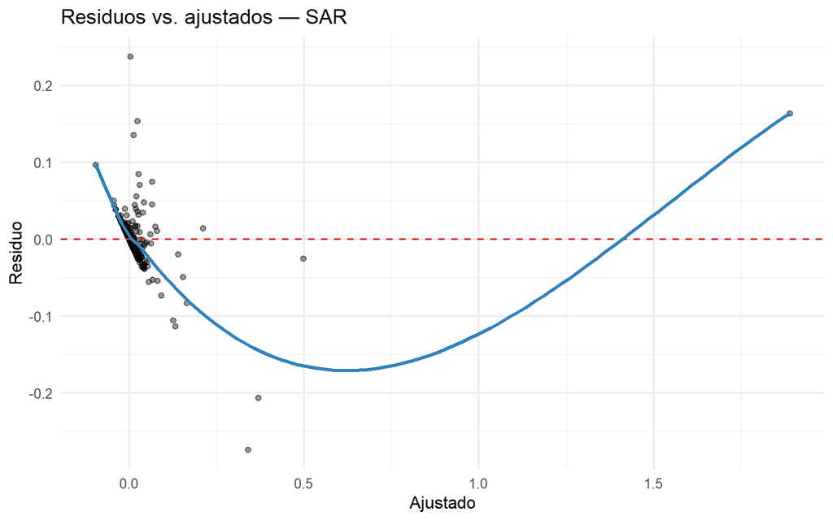

```r
data.frame(
  ajustado = fitted(mejor_modelo_espacial),
  residuo  = residuals(mejor_modelo_espacial)
) %>%
  ggplot(aes(x = ajustado, y = residuo)) +
  geom_point(alpha = 0.4) +
  geom_hline(yintercept = 0, color = "#de2d26", linetype = "dashed") +
  geom_smooth(method = "loess", se = FALSE, color = "#3182bd") +
  labs(title = sprintf("Residuos vs. ajustados — %s", nombre_mejor), x = "Ajustado", y = "Residuo") +
  theme_minimal(base_size = 12)
```

### QQ-plot de residuos (normalidad)

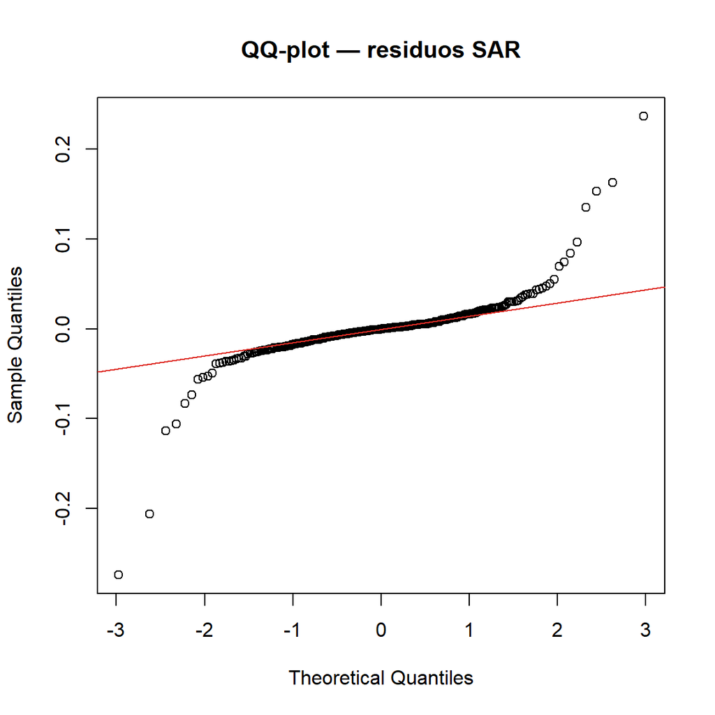

```r
qqnorm(residuals(mejor_modelo_espacial), main = sprintf("QQ-plot — residuos %s", nombre_mejor))
qqline(residuals(mejor_modelo_espacial), col = "#de2d26")
```

### Autocorrelación espacial residual — ¿el modelo ya “limpió” el patrón espacial?

Si el modelo espacial es adecuado, sus residuos **ya no** deberían mostrar autocorrelación espacial significativa (a diferencia del OLS del principio).

```r
moran_residuos_final <- moran.test(
  as.numeric(residuals(mejor_modelo_espacial)),
  pesos_espaciales_cs, zero.policy = TRUE
)

print(moran_residuos_final)
```

```
##
##  Moran I test under randomisation
##
## data:  as.numeric(residuals(mejor_modelo_espacial))
## weights: pesos_espaciales_cs
##
## Moran I statistic standard deviate = 1.7503, p-value = 0.04003
## alternative hypothesis: greater
## sample estimates:
## Moran I statistic       Expectation          Variance
##      0.0471047080     -0.0029239766      0.0008169788
```

```r
cat(sprintf(
  "\n%s\n",
  if (moran_residuos_final$p.value >= 0.05) {
    sprintf("Los residuos del %s ya NO muestran autocorrelacion espacial significativa - el modelo capturo adecuadamente el patron espacial.", nombre_mejor)
  } else {
    sprintf("Los residuos del %s AUN muestran autocorrelacion espacial - la especificacion podria mejorarse (mas variables, otra estructura de vecindad).", nombre_mejor)
  }
))
```

```
##
## Los residuos del SAR AUN muestran autocorrelacion espacial - la especificacion podria mejorarse (mas variables, otra estructura de vecindad).
```

### Mapa: residuales del modelo espacial

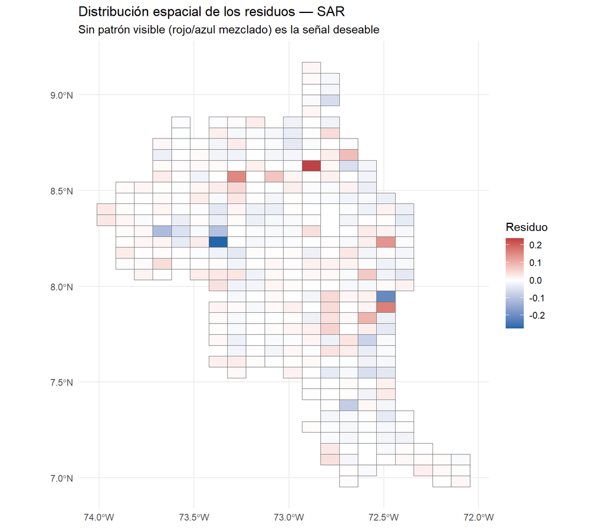

```r
cross_section_sf %>%
  mutate(residuo = as.numeric(residuals(mejor_modelo_espacial))) %>%
  ggplot() +
  geom_sf(aes(fill = residuo), color = "gray40", linewidth = 0.15) +
  scale_fill_gradient2(low = "#2166ac", mid = "white", high = "#b2182b", midpoint = 0, name = "Residuo") +
  labs(
    title    = sprintf("Distribución espacial de los residuos — %s", nombre_mejor),
    subtitle = "Sin patrón visible (rojo/azul mezclado) es la señal deseable"
  ) +
  theme_minimal(base_size = 11)
```

### Predicho vs. observado

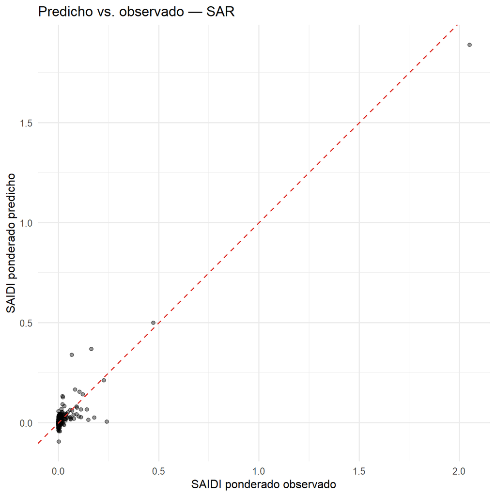

```r
data.frame(
  observado = cross_section_sf$SAIDI_ponderado,
  predicho  = fitted(mejor_modelo_espacial)
) %>%
  ggplot(aes(x = observado, y = predicho)) +
  geom_point(alpha = 0.4) +
  geom_abline(slope = 1, intercept = 0, color = "#de2d26", linetype = "dashed") +
  labs(title = sprintf("Predicho vs. observado — %s", nombre_mejor),
       x = "SAIDI ponderado observado", y = "SAIDI ponderado predicho") +
  theme_minimal(base_size = 12)
```

## Interpretación del parámetro espacial

```r
if (nombre_mejor == "SAR") {
  rho_valor <- modelo_sar$rho
  cat(sprintf(
    "rho (SAR) = %.4f. %s\n", rho_valor,
    if (rho_valor > 0) {
      "Positivo: el SAIDI de un cuadrante tiende a ser mas alto cuando el de sus vecinos tambien lo es - consistente con la hipotesis de exposicion regional compartida (clima, eventos catastroficos, sismos)."
    } else {
      "Negativo: patron menos intuitivo, revisar antes de interpretar sustantivamente."
    }
  ))
} else {
  lambda_valor <- modelo_sem$lambda
  cat(sprintf(
    "lambda (SEM) = %.4f. %s\n", lambda_valor,
    if (lambda_valor > 0) {
      "Positivo: hay factores NO observados que afectan simultaneamente a cuadrantes vecinos (p. ej. calidad de mantenimiento historico de un mismo circuito, no capturada por las variables del modelo)."
    } else {
      "Negativo: patron menos intuitivo, revisar antes de interpretar sustantivamente."
    }
  ))
}
```

```
## rho (SAR) = -0.3153. Negativo: patron menos intuitivo, revisar antes de interpretar sustantivamente.
```

**Resumen de la sección:** se usa un corte transversal ponderado (más peso a lo reciente, vía suma de dígitos) porque `lagsarlm`/`errorsarlm` no operan sobre panel. El test de Moran sobre los residuos del OLS y los tests LM justifican empíricamente si conviene SAR o SEM en lugar de asumirlo; el AIC y el test de razón de verosimilitud deciden entre ambos; y el Moran’s I sobre los residuos del modelo elegido confirma si la estructura espacial quedó bien capturada. Esta sección es complementaria a la Parte 1b (rezago espacial como covariable en el panel semanal) — aquí se responde formalmente “¿es SAR o SEM?”, mientras que el panel resuelve “¿mejora el pronóstico semanal?”.

# Parte 9 — Resumen y comparación de métricas: ¿cuál modelo es mejor?

## Selección de variables para el modelo estructural (corte transversal)

Las variables de `formula_espacial` (Parte 8) se eligieron inicialmente por criterio de dominio. Aquí se valida esa elección con selección estadística formal (*stepwise* bidireccional por AIC), se revisa colinealidad, y se prueban especificaciones alternativas de robustez antes de fijar la versión final.

```r
library(MASS)
select <- dplyr::select   # MASS redefine select(); se refuerza por seguridad
filter <- dplyr::filter

modelo_completo_cs <- lm(
  SAIDI_ponderado ~ n_elementos + prop_transformadores + longitud_red_km +
    densidad_terminales + n_circuitos_cuadrante +
    prop_estrato_1 + prop_estrato_2 + prop_no_residencial +
    edad_activo_mas_viejo_anios + PROM_CANT_MODIFICACIONES +
    ndvi_promedio + dist_sismo_prom_km + precip_promedio,
  data = cross_section_sf
)

modelo_stepwise <- stepAIC(modelo_completo_cs, direction = "both", trace = FALSE)
summary(modelo_stepwise)
```

```
##
## Call:
## lm(formula = SAIDI_ponderado ~ n_elementos + longitud_red_km +
##     n_circuitos_cuadrante + prop_estrato_2 + prop_no_residencial +
##     edad_activo_mas_viejo_anios + PROM_CANT_MODIFICACIONES +
##     ndvi_promedio, data = cross_section_sf)
##
## Residuals:
##       Min        1Q    Median        3Q       Max
## -0.290851 -0.009790 -0.000464  0.010250  0.231739
##
## Coefficients:
##                               Estimate Std. Error t value Pr(>|t|)
## (Intercept)                 -1.311e-01  2.217e-02  -5.913 8.31e-09 ***
## n_elementos                  3.886e-04  1.899e-05  20.464  < 2e-16 ***
## longitud_red_km             -1.016e-03  1.330e-04  -7.642 2.29e-13 ***
## n_circuitos_cuadrante        7.612e-03  1.520e-03   5.007 8.96e-07 ***
## prop_estrato_2               1.096e-02  6.292e-03   1.742  0.08235 .
## prop_no_residencial         -1.339e-01  5.583e-02  -2.399  0.01700 *
## edad_activo_mas_viejo_anios -2.398e-02  4.584e-03  -5.232 2.97e-07 ***
## PROM_CANT_MODIFICACIONES     1.498e-02  9.109e-03   1.645  0.10096
## ndvi_promedio                6.778e-02  2.596e-02   2.610  0.00945 **
## ---
## Signif. codes:  0 '***' 0.001 '**' 0.01 '*' 0.05 '.' 0.1 ' ' 1
##
## Residual standard error: 0.0361 on 334 degrees of freedom
## Multiple R-squared:  0.9069, Adjusted R-squared:  0.9046
## F-statistic: 406.6 on 8 and 334 DF,  p-value: < 2.2e-16
```

**Variables eliminadas:** el *stepwise* retira automáticamente las que no reducen el AIC al permanecer en el modelo — revisa el `summary()` de arriba para ver la especificación final retenida en tu corrida (el listado exacto puede variar ahora que se agregaron las variables reales de estrato y activos, respecto a la versión anterior con estrato municipal).

## Diagnóstico de colinealidad

```r
car::vif(modelo_stepwise)
```

```
##                 n_elementos             longitud_red_km
##                   10.147644                    6.349417
##       n_circuitos_cuadrante              prop_estrato_2
##                    6.233096                    1.077628
##         prop_no_residencial edad_activo_mas_viejo_anios
##                    1.060332                    1.167270
##    PROM_CANT_MODIFICACIONES               ndvi_promedio
##                    1.071787                    1.144360
```

`n_elementos` y `longitud_red_km` mostraban VIF ~7.6-7.9 en la versión anterior del modelo (colinealidad moderada — ambas capturan, en parte, el tamaño/exposición física del cuadrante). Revisa el VIF de arriba con las variables nuevas incluidas; si alguna de `edad_activo_mas_viejo_anios`/`PROM_CANT_MODIFICACIONES` muestra VIF alto frente a las de infraestructura, aplicar el mismo tipo de prueba de robustez que sigue.

```r
# Version A: sin longitud_red_km
modelo_sin_longitud <- lm(
  SAIDI_ponderado ~ n_elementos + prop_transformadores +
    densidad_terminales + prop_estrato_1 + prop_estrato_2 +
    edad_activo_mas_viejo_anios + PROM_CANT_MODIFICACIONES + precip_promedio,
  data = cross_section_sf
)

# Version B: sin n_elementos
modelo_sin_elementos <- lm(
  SAIDI_ponderado ~ prop_transformadores + longitud_red_km +
    densidad_terminales + prop_estrato_1 + prop_estrato_2 +
    edad_activo_mas_viejo_anios + PROM_CANT_MODIFICACIONES + precip_promedio,
  data = cross_section_sf
)

# Version C: con interaccion longitud_red_km x n_elementos
modelo_interaccion <- lm(
  SAIDI_ponderado ~ prop_transformadores + longitud_red_km * n_elementos +
    densidad_terminales + prop_estrato_1 + prop_estrato_2 +
    edad_activo_mas_viejo_anios + PROM_CANT_MODIFICACIONES + precip_promedio,
  data = cross_section_sf
)

comparacion_robustez <- tibble(
  especificacion = c("Stepwise (ambas variables)", "Sin longitud_red_km",
                     "Sin n_elementos", "Con interaccion"),
  AIC = c(AIC(modelo_stepwise), AIC(modelo_sin_longitud),
          AIC(modelo_sin_elementos), AIC(modelo_interaccion)),
  R2_ajustado = c(summary(modelo_stepwise)$adj.r.squared,
                   summary(modelo_sin_longitud)$adj.r.squared,
                   summary(modelo_sin_elementos)$adj.r.squared,
                   summary(modelo_interaccion)$adj.r.squared)
) %>%
  arrange(AIC)

kable(comparacion_robustez, digits = 4,
      caption = "Pruebas de robustez frente a la colinealidad n_elementos / longitud_red_km") %>%
  kable_styling(bootstrap_options = c("striped"), full_width = FALSE)
```

Pruebas de robustez frente a la colinealidad n_elementos / longitud_red_km

| especificacion | AIC | R2_ajustado |
| --- | --- | --- |
| Con interaccion | -1548.3616 | 0.9548 |
| Stepwise (ambas variables) | -1294.2135 | 0.9046 |
| Sin longitud_red_km | -1230.5672 | 0.8852 |
| Sin n_elementos | -891.2956 | 0.6913 |

**Interpretación:** `longitud_red_km` con signo negativo no debe leerse como “más cable físico reduce el riesgo” en sentido de exposición directa. Es más plausible que capture un efecto de **composición espacial**: cuadrantes con redes muy extensas tienden a ser zonas rurales grandes con baja densidad de carga, mientras que redes cortas pero con alta `prop_transformadores` tienden a concentrarse en zonas urbanas densas, donde una misma falla afecta proporcionalmente a más usuarios servidos por esa infraestructura puntual. Se documenta esta distinción explícitamente para anticipar la pregunta en la sustentación de tesis — el coeficiente es un efecto de composición, no de exposición física directa.

```r
# Especificacion final para el modelo estructural de SAIDI, tras
# stepwise + verificacion de robustez
modelo_final_saidi_cs <- modelo_stepwise

summary(modelo_final_saidi_cs)
```

```
##
## Call:
## lm(formula = SAIDI_ponderado ~ n_elementos + longitud_red_km +
##     n_circuitos_cuadrante + prop_estrato_2 + prop_no_residencial +
##     edad_activo_mas_viejo_anios + PROM_CANT_MODIFICACIONES +
##     ndvi_promedio, data = cross_section_sf)
##
## Residuals:
##       Min        1Q    Median        3Q       Max
## -0.290851 -0.009790 -0.000464  0.010250  0.231739
##
## Coefficients:
##                               Estimate Std. Error t value Pr(>|t|)
## (Intercept)                 -1.311e-01  2.217e-02  -5.913 8.31e-09 ***
## n_elementos                  3.886e-04  1.899e-05  20.464  < 2e-16 ***
## longitud_red_km             -1.016e-03  1.330e-04  -7.642 2.29e-13 ***
## n_circuitos_cuadrante        7.612e-03  1.520e-03   5.007 8.96e-07 ***
## prop_estrato_2               1.096e-02  6.292e-03   1.742  0.08235 .
## prop_no_residencial         -1.339e-01  5.583e-02  -2.399  0.01700 *
## edad_activo_mas_viejo_anios -2.398e-02  4.584e-03  -5.232 2.97e-07 ***
## PROM_CANT_MODIFICACIONES     1.498e-02  9.109e-03   1.645  0.10096
## ndvi_promedio                6.778e-02  2.596e-02   2.610  0.00945 **
## ---
## Signif. codes:  0 '***' 0.001 '**' 0.01 '*' 0.05 '.' 0.1 ' ' 1
##
## Residual standard error: 0.0361 on 334 degrees of freedom
## Multiple R-squared:  0.9069, Adjusted R-squared:  0.9046
## F-statistic: 406.6 on 8 and 334 DF,  p-value: < 2.2e-16
```

Los modelos construidos en este documento no son directamente comparables entre sí sin aclarar el contexto: usan **datos distintos** (panel semanal vs. corte transversal ponderado), **métricas distintas** (RMSE/R² en test vs. AIC), y responden **preguntas distintas** (pronóstico semana a semana vs. explicación estructural del riesgo promedio por cuadrante). Esta sección los pone en una sola tabla, señalando explícitamente qué es y qué no es comparable.

## Advertencia sobre `FE cuadrante+semana`

Este modelo **no puede evaluarse en test** con el split temporal usado: tiene un efecto fijo por semana, y las semanas del conjunto de prueba nunca aparecieron en entrenamiento — `feols()` no puede predecir el efecto fijo de una semana que no vio nunca (no es un error de código, es una limitación estructural de cualquier modelo con efectos fijos temporales evaluado con separación temporal). Se excluye de la comparación de pronóstico y se conserva únicamente como ejercicio de **inferencia dentro de muestra** (para entender qué tanto explican las variables controlando por shocks semanales comunes).

```r
tabla_resumen <- tribble(
  ~Modelo, ~Datos, ~Metrica_principal, ~Valor, ~Uso_valido, ~Interpretabilidad,

  "Pooled OLS", "Panel semanal (test)", "RMSE (log SAIDI)", resultados$RMSE_log[resultados$modelo == "Pooled OLS"],
    "Pronostico fuera de muestra", "Alta",

  "FE cuadrante", "Panel semanal (test)", "RMSE (log SAIDI)", resultados$RMSE_log[resultados$modelo == "FE cuadrante"],
    "Pronostico fuera de muestra", "Alta",

  "FE cuadrante+semana", "Panel semanal", "Within R2 (dentro de muestra)", 0.109,
    "Solo inferencia dentro de muestra - NO pronostico (ver advertencia arriba)", "Media",

  "Random Forest", "Panel semanal (test)", "RMSE (log SAIDI)", resultados$RMSE_log[resultados$modelo == "Random Forest"],
    "Pronostico fuera de muestra", "Baja",

  "SAR (corte transversal)", "Corte transversal ponderado", "AIC", AIC(modelo_sar),
    "Explicacion estructural del riesgo promedio - NO pronostico semanal", "Media",

  "SEM (corte transversal)", "Corte transversal ponderado", "AIC", AIC(modelo_sem),
    "Explicacion estructural del riesgo promedio - NO pronostico semanal", "Media"
)

kable(tabla_resumen, digits = 4,
      caption = "Resumen comparativo de todas las especificaciones - SAIDI") %>%
  kable_styling(bootstrap_options = c("striped", "hover"), full_width = FALSE) %>%
  column_spec(5, width = "25%")
```

Resumen comparativo de todas las especificaciones - SAIDI

| Modelo | Datos | Metrica_principal | Valor | Uso_valido | Interpretabilidad |
| --- | --- | --- | --- | --- | --- |
| Pooled OLS | Panel semanal (test) | RMSE (log SAIDI) | 0.1666 | Pronostico fuera de muestra | Alta |
| FE cuadrante | Panel semanal (test) | RMSE (log SAIDI) | 0.1341 | Pronostico fuera de muestra | Alta |
| FE cuadrante+semana | Panel semanal | Within R2 (dentro de muestra) | 0.1090 | Solo inferencia dentro de muestra - NO pronostico (ver advertencia arriba) | Media |
| Random Forest | Panel semanal (test) | RMSE (log SAIDI) | 0.1195 | Pronostico fuera de muestra | Baja |
| SAR (corte transversal) | Corte transversal ponderado | AIC | -1305.1907 | Explicacion estructural del riesgo promedio - NO pronostico semanal | Media |
| SEM (corte transversal) | Corte transversal ponderado | AIC | -1263.8784 | Explicacion estructural del riesgo promedio - NO pronostico semanal | Media |

## Comparación dentro de cada grupo (las que sí son comparables entre sí)

**Grupo A — Pronóstico semanal (comparables por RMSE en test):**

```r
resultados %>%
  filter(modelo != "FE cuadrante+semana") %>%
  arrange(RMSE_log) %>%
  kable(digits = 4, caption = "Grupo A: modelos de pronostico, ordenados por RMSE (menor es mejor)") %>%
  kable_styling(bootstrap_options = c("striped"), full_width = FALSE)
```

Grupo A: modelos de pronostico, ordenados por RMSE (menor es mejor)

| modelo | RMSE_log | MAE_log | R2_log |
| --- | --- | --- | --- |
| Random Forest | 0.1195 | 0.0609 | 0.1902 |
| FE cuadrante | 0.1341 | 0.0517 | 0.1087 |
| Pooled OLS | 0.1666 | 0.0627 | 0.0558 |

**Grupo B — Explicación estructural del riesgo promedio (comparables por AIC):**

```r
comparacion_aic %>%
  kable(digits = 2, caption = "Grupo B: modelos estructurales, ordenados por AIC (menor es mejor)") %>%
  kable_styling(bootstrap_options = c("striped"), full_width = FALSE)
```

Grupo B: modelos estructurales, ordenados por AIC (menor es mejor)

| modelo | AIC | logLik |
| --- | --- | --- |
| SAR | -1305.19 | 667.60 |
| OLS | -1265.79 | 646.90 |
| SEM | -1263.88 | 646.94 |